# **Tugas-Pertemuan-2**

Elardian Putera Ramadhan (G1401231042)

2025-08-30

## **Library/Packages**

*Package* R yang akan digunakan pada perkuliahan Analisis Deret Waktu sesi UTS adalah: `forecast`, `graphics`, `TTR`, `TSA` . Jika *package* tersebut belum ada, silakan install terlebih dahulu.

```r
#install.packages("forecast")
#install.packages("graphics")
#install.packages("TTR")
#install.packages("TSA")
```

Jika sudah ada, silakan panggil library *package* tersebut.

```r
library("forecast")
```

```r
library("graphics")
library("TTR")
library("TSA")
```

## **Impor Data**

```r
data <- read.csv("C:/Users/Putera Ramadhan/OneDrive/Documents/IPB University/Semester 5/STA1341 - Metode Peramalan Deret Waktu/UTS/Praktikum/MPDW/Pertemuan 1/Data/Reversed Bitcoin Historical Price.csv")
data$Date <- as.Date(data$Date, format="%m/%d/%Y")
# Menghapus koma (',') sebelum mengubah tipe data menjadi numerik
data$Price <- as.numeric(gsub(",", "", data$Price))
data$Open <- as.numeric(gsub(",", "", data$Open))
data$High <- as.numeric(gsub(",", "", data$High))
data$Low <- as.numeric(gsub(",", "", data$Low))
# Menampilkan 6 baris pertama data
head(data)
```

```
##         Date Price  Open  High   Low    Vol. Change..
## 1 2016-01-03 448.3 433.7 462.9 423.1 457.61K    3.36%
## 2 2016-01-10 385.0 448.3 451.1 350.4 735.95K  -14.11%
## 3 2016-01-17 388.6 385.0 425.7 373.2 688.23K    0.93%
## 4 2016-01-24 377.8 388.6 405.4 363.5 484.64K   -2.79%
## 5 2016-01-31 376.7 377.8 391.8 365.3 465.80K   -0.29%
## 6 2016-02-07 390.1 376.7 392.6 371.4 420.40K    3.56%
```

```r
# Ambil data baris ke 253 sampai baris ke 378
data_subset <- data[253:378, ]
# Tampilkan data subset
head(data_subset)
```

```
##           Date   Price    Open    High     Low    Vol. Change..
## 253 2020-11-01 14828.4 13795.5 15955.2 13214.2 969.23K    7.47%
## 254 2020-11-08 16071.0 14826.6 16474.1 14720.7 849.61K    8.38%
## 255 2020-11-15 18687.2 16074.7 18966.0 15782.3 985.86K   16.28%
## 256 2020-11-22 17730.7 18394.6 19486.7 16235.2   1.15M   -5.12%
## 257 2020-11-29 19146.5 17729.7 19897.4 17530.4 883.70K    7.99%
## 258 2020-12-06 18808.9 19146.0 19424.6 17600.1 642.93K   -1.76%
```

## **Eksplorasi Data**

`View()` : menampilkan data dalam bentuk tabel, `str()` : menampilkan struktur data, `dim()` : menampilkan dimensi data

```r
View(data_subset)
str(data_subset)
```

```
## 'data.frame':    126 obs. of  7 variables:
##  $ Date    : Date, format: "2020-11-01" "2020-11-08" ...
##  $ Price   : num  14828 16071 18687 17731 19147 ...
##  $ Open    : num  13796 14827 16075 18395 17730 ...
##  $ High    : num  15955 16474 18966 19487 19897 ...
##  $ Low     : num  13214 14721 15782 16235 17530 ...
##  $ Vol.    : chr  "969.23K" "849.61K" "985.86K" "1.15M" ...
##  $ Change..: chr  "7.47%" "8.38%" "16.28%" "-5.12%" ...
```

```r
dim(data_subset)
```

```
## [1] 126   7
```

Mengubah data agar terbaca sebagai data deret waktu dengan fungsi `ts()`.

```r
data_subset.ts <- ts(data_subset$Price)
```

Menampilkan ringkasan data

```r
summary(data_subset.ts)
```

```
##    Min. 1st Qu.  Median    Mean 3rd Qu.    Max.
##   14828   21514   34664   35020   46566   64399
```

Membuat plot deret waktu

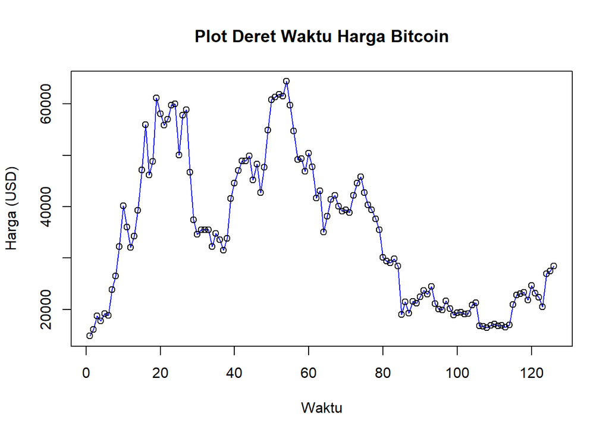

```r
ts.plot(data_subset.ts,
     main = "Plot Deret Waktu Harga Bitcoin",
     xlab = "Waktu",
     ylab = "Harga (USD)",
     col = "blue")
points(data_subset.ts)
```

```r
# menyimpan plot
dev.copy(png, 'Plot/Plot Data Harga Bitcoin.png')
```

```r
dev.off()
```

## **Single Moving Average & Double Moving Average**

### **Pembagian Data**

Pembagian data latih dan data uji dilakukan dengan perbandingan 80% data latih dan 20% data uji.

```r
# Hitung jumlah data
n <- nrow(data_subset)
# Tentukan proporsi data latih (80%)
n_train <- floor(0.8 * n)
# Bagi data menjadi data latih dan data uji
training_ma <- data_subset[1:n_train, ]
testing_ma <- data_subset[(n_train + 1):n, ]
# Ubah ke dalam format time series
train_ma.ts <- ts(training_ma$Price)
test_ma.ts <- ts(testing_ma$Price)
```

### **Eksplorasi**

Eksplorasi data dilakukan pada keseluruhan data, data latih serta data uji menggunakan plot data deret waktu.

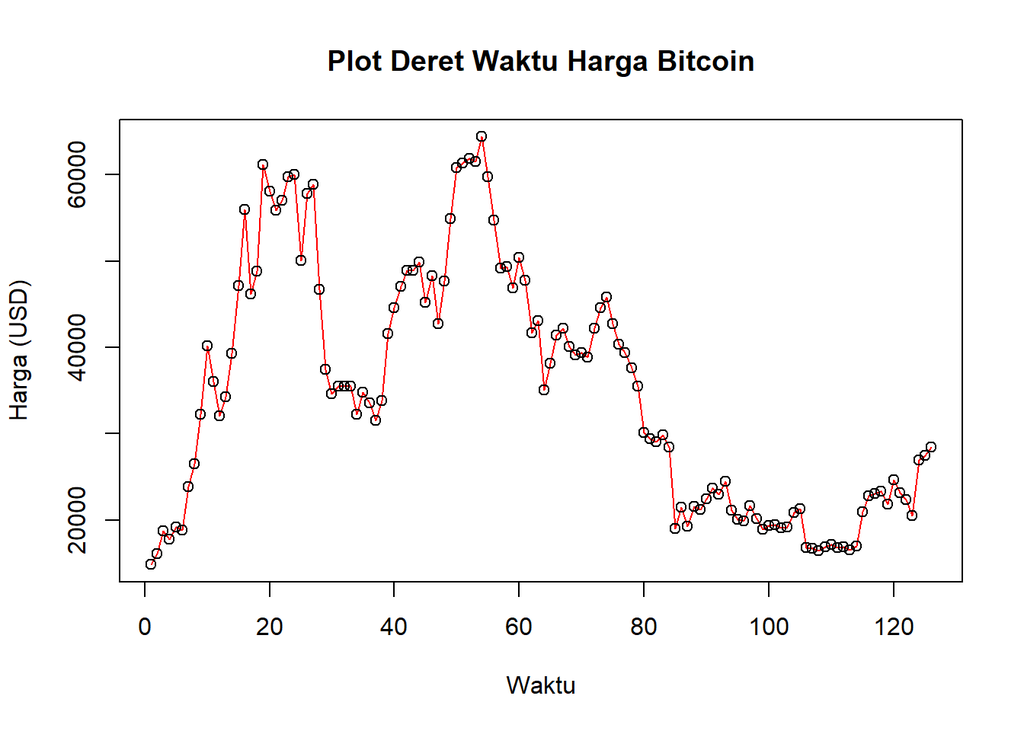

```r
# Eksplorasi keseluruhan data
plot(data_subset.ts, main = "Plot Deret Waktu Harga Bitcoin",
     xlab = "Waktu", ylab = "Harga (USD)", col = "red")
points(data_subset.ts)
```

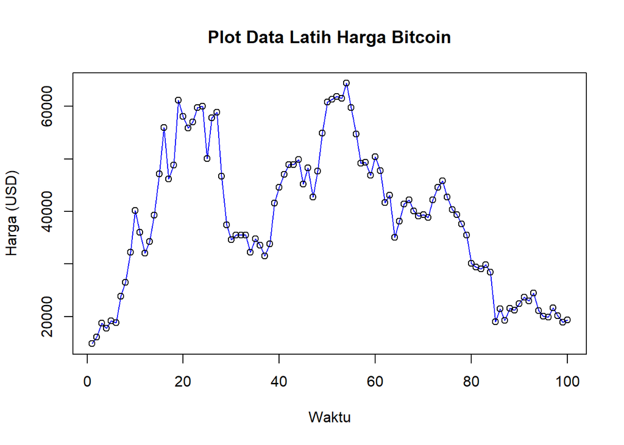

```r
# Eksplorasi data latih
plot(train_ma.ts, main = "Plot Data Latih Harga Bitcoin",
     xlab = "Waktu", ylab = "Harga (USD)", col = "blue")
points(train_ma.ts)
```

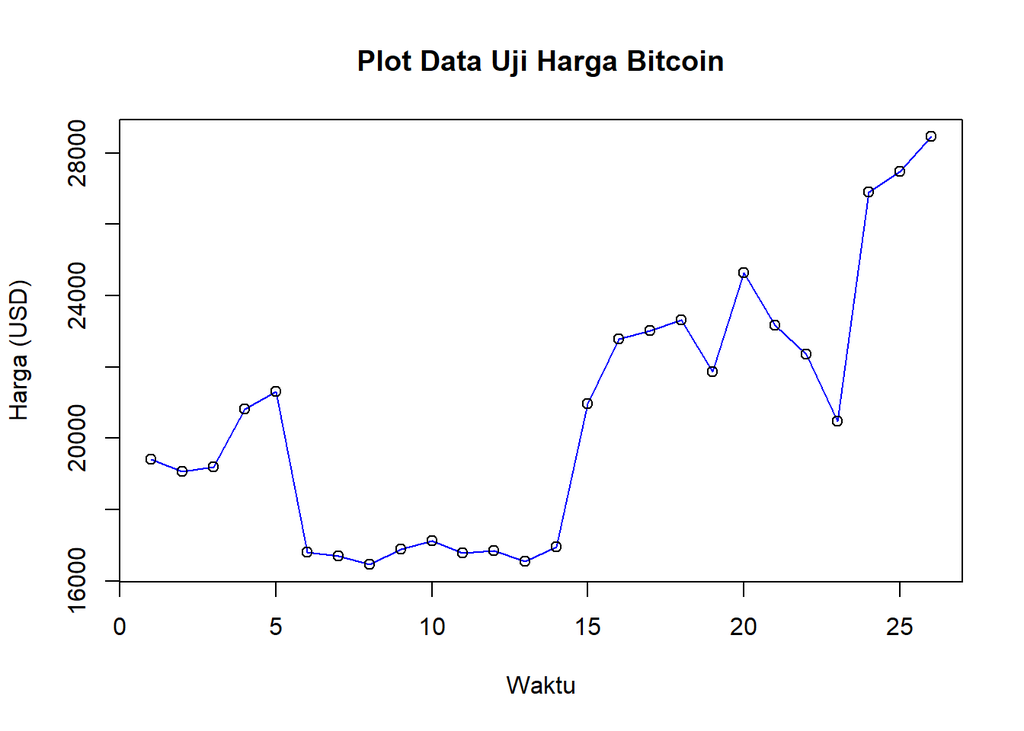

```r
# Eksplorasi data uji
plot(test_ma.ts, main = "Plot Data Uji Harga Bitcoin",
     xlab = "Waktu", ylab = "Harga (USD)", col = "blue")
points(test_ma.ts)
```

Eksplorasi data juga dapat dilakukan menggunakan package `ggplot2` dengan terlebih dahulu memanggil library *package* `ggplot2`.

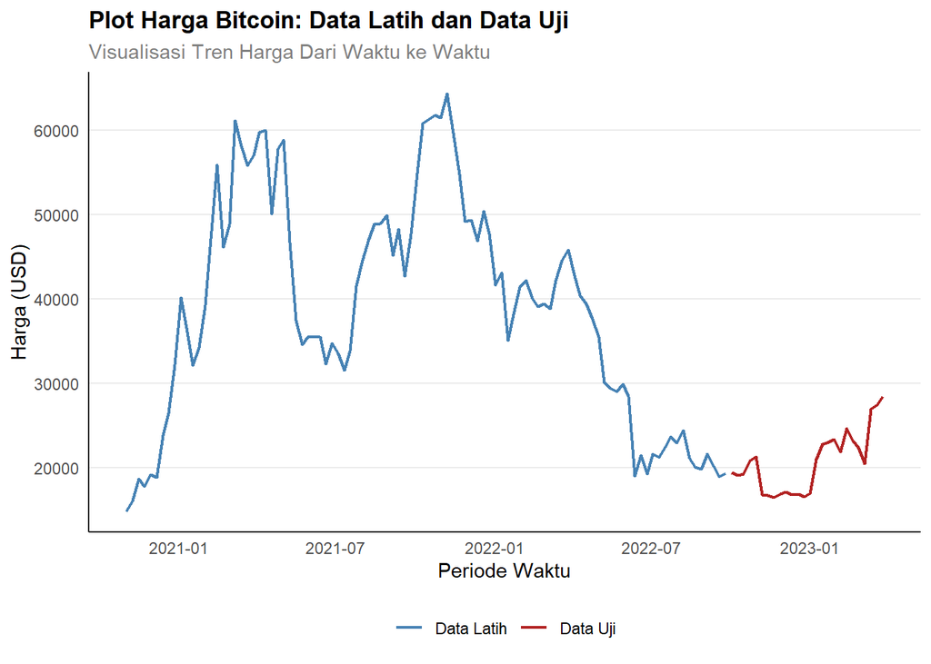

```r
library(ggplot2)
ggplot() +
  geom_line(data = training_ma, aes(x = Date, y = Price, col = "Data Latih"), linewidth = 0.8) +
  geom_line(data = testing_ma, aes(x = Date, y = Price, col = "Data Uji"), linewidth = 0.8) +
  labs(title = "Plot Harga Bitcoin: Data Latih dan Data Uji",
       subtitle = "Visualisasi Tren Harga Dari Waktu ke Waktu",
       x = "Periode Waktu",
       y = "Harga (USD)",
       color = "Keterangan") +
  scale_colour_manual(name = "Keterangan:",
                      values = c("Data Latih" = "steelblue", "Data Uji" = "firebrick")) +
  theme_minimal() +
  theme(
    legend.position = "bottom",
    legend.title = element_blank(), # Hilangkan judul legend agar lebih minimalis
    plot.title = element_text(face = "bold"),
    plot.subtitle = element_text(color = "gray50"),
    panel.grid.minor = element_blank(),
    panel.grid.major.x = element_blank(), # Hilangkan grid vertikal
    axis.line = element_line(color = "black")
  )
```

## **Single Moving Average (SMA)**

Ide dasar dari Single Moving Average (SMA) adalah data suatu periode dipengaruhi oleh data periode sebelumnya. Metode pemulusan ini cocok digunakan untuk pola data stasioner atau konstan. Prinsip dasar metode pemulusan ini adalah data pemulusan pada periode ke-t merupakan rata rata dari m buah data pada periode ke-t hingga periode ke (t-m+1).

$$S_t = \frac{1}{m} \sum_{i=t-m+1}^{t} X_i$$

Data pemulusan pada periode ke-t selanjutnya digunakan sebagai nilai peramalan pada periode ke t+1.

$$F_t = S_{t-1}, F_{n,h} = S_n$$

Pemulusan menggunakan metode SMA dilakukan dengan fungsi `SMA()`. Dalam hal ini akan dilakukan pemulusan dengan parameter `m=3`.

```r
data_subset.sma <- SMA(train_ma.ts, n = 3)
data_subset.sma
```

```
## Time Series:
## Start = 1
## End = 100
## Frequency = 1
##   [1]       NA       NA 16528.87 17496.30 18521.47 18562.03 20599.80 23035.77
##   [9] 27497.23 32933.20 36121.57 36086.77 34130.50 35209.53 40236.13 47449.67
##  [17] 49743.03 50305.33 52062.53 56048.10 58383.87 57005.40 57557.07 58950.07
##  [25] 56626.40 55979.30 55578.70 54452.00 47665.73 39580.57 35850.97 35190.70
##  [33] 35500.30 34408.10 34166.53 33498.93 33257.33 32951.33 35632.37 39997.57
##  [41] 44416.47 46857.17 48284.80 49230.43 47992.47 47795.67 45385.13 46220.13
##  [49] 48432.07 54490.17 59038.70 61337.90 61545.50 62574.20 61866.70 59627.37
##  [57] 54559.57 51091.87 48455.30 48859.03 48333.53 46605.47 44169.00 39948.07
##  [65] 38781.00 38219.37 40596.03 41235.87 40470.33 39533.87 39108.53 40147.70
##  [73] 41865.10 44197.33 44375.33 42986.67 40855.67 39150.00 37512.00 34399.47
##  [81] 31661.00 29514.03 29442.00 29098.27 25751.40 22959.93 19906.53 20773.53
##  [89] 20680.20 21752.60 22434.83 23012.93 23673.63 22841.87 21871.77 20334.73
##  [97] 20505.23 20531.77 20229.70 19450.20
```

Data pemulusan pada periode ke-t selanjutnya digunakan sebagai nilai peramalan pada periode ke t+1 sehingga hasil peramalan 1 periode kedepan adalah sebagai berikut.

```r
data_subset.ramal_sma <- c(NA, data_subset.sma)
# Menampilkan hasil peramalan SMA 1 periode ke depan
data_subset.ramal_sma
```

```
##   [1]       NA       NA       NA 16528.87 17496.30 18521.47 18562.03 20599.80
##   [9] 23035.77 27497.23 32933.20 36121.57 36086.77 34130.50 35209.53 40236.13
##  [17] 47449.67 49743.03 50305.33 52062.53 56048.10 58383.87 57005.40 57557.07
##  [25] 58950.07 56626.40 55979.30 55578.70 54452.00 47665.73 39580.57 35850.97
##  [33] 35190.70 35500.30 34408.10 34166.53 33498.93 33257.33 32951.33 35632.37
##  [41] 39997.57 44416.47 46857.17 48284.80 49230.43 47992.47 47795.67 45385.13
##  [49] 46220.13 48432.07 54490.17 59038.70 61337.90 61545.50 62574.20 61866.70
##  [57] 59627.37 54559.57 51091.87 48455.30 48859.03 48333.53 46605.47 44169.00
##  [65] 39948.07 38781.00 38219.37 40596.03 41235.87 40470.33 39533.87 39108.53
##  [73] 40147.70 41865.10 44197.33 44375.33 42986.67 40855.67 39150.00 37512.00
##  [81] 34399.47 31661.00 29514.03 29442.00 29098.27 25751.40 22959.93 19906.53
##  [89] 20773.53 20680.20 21752.60 22434.83 23012.93 23673.63 22841.87 21871.77
##  [97] 20334.73 20505.23 20531.77 20229.70 19450.20
```

Selanjutnya dilakukan peramalan sebanyak 26 periode sesuai dengan jumlah data uji. Pada metode SMA, seluruh hasil peramalan untuk 26 periode ke depan akan memiliki nilai yang sama dengan hasil ramalan satu periode ke depan.

```r
#  Forecasting 26 periode ke depan
data.gab<-cbind(
  aktual=c(data_subset.ts),
  pemulusan=c(data_subset.sma,rep(NA,26)),
  ramalan=c(data_subset.ramal_sma,rep(data_subset.ramal_sma[length(data_subset.ramal_sma)],25)))

data.gab
```

```
##         aktual pemulusan  ramalan
##   [1,] 14828.4        NA       NA
##   [2,] 16071.0        NA       NA
##   [3,] 18687.2  16528.87       NA
##   [4,] 17730.7  17496.30 16528.87
##   [5,] 19146.5  18521.47 17496.30
##   [6,] 18808.9  18562.03 18521.47
##   [7,] 23844.0  20599.80 18562.03
##   [8,] 26454.4  23035.77 20599.80
##   [9,] 32193.3  27497.23 23035.77
##  [10,] 40151.9  32933.20 27497.23
##  [11,] 36019.5  36121.57 32933.20
##  [12,] 32088.9  36086.77 36121.57
##  [13,] 34283.1  34130.50 36086.77
##  [14,] 39256.6  35209.53 34130.50
```

[output cut: 112 more lines]

Adapun plot data deret waktu dari hasil peramalan yang dilakukan adalah sebagai berikut.

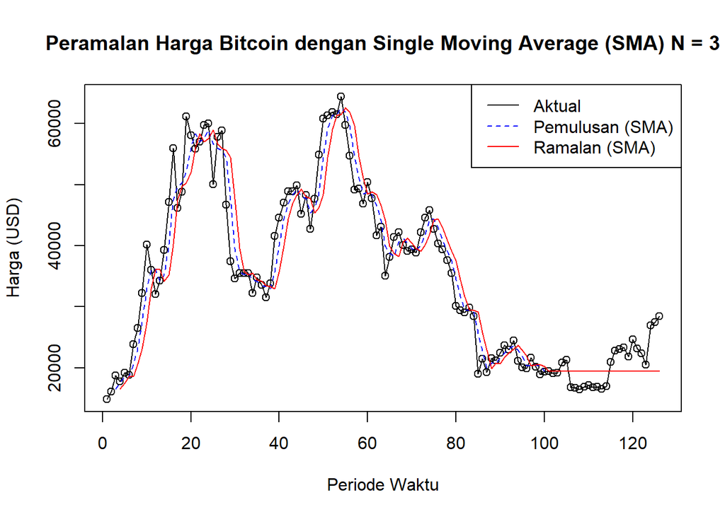

```r
# Plot hasil peramalan SMA
ts.plot(data_subset.ts, xlab = "Periode Waktu", ylab = "Harga (USD)", main = "Peramalan Harga Bitcoin dengan Single Moving Average (SMA) N = 3")
points(data_subset.ts)
lines(data.gab[,2], col = "blue", lty = 2) # Pemulusan
lines(data.gab[,3], col = "red", lty = 1)  # Ramalan
legend("topright", legend = c("Aktual", "Pemulusan (SMA)", "Ramalan (SMA)"), col = c("black", "blue", "red"), lty = c(1, 2, 1))
```

Selanjutnya perhitungan akurasi dilakukan dengan ukuran akurasi *Sum Squares Error* (SSE), *Mean Square Error* (MSE) dan *Mean Absolute Percentage Error* (MAPE). Perhitungan akurasi dilakukan baik pada data latih maupun pada data uji.

$$SSE = \sum_{t=1}^{n} (y_t - \hat{y}_t)^2$$
$$MSE = \frac{1}{n} \sum_{t=1}^{n} (y_t - \hat{y}_t)^2$$
$$MAPE = \frac{1}{n} \sum_{t=1}^{n} \left|\frac{y_t -
\hat{y}_t}{y_t}\right| * 100$$

### **Akurasi Data Latih**

```r
# Menghitung nilai keakuratan data latih
error_train.sma <- train_ma.ts - data_subset.ramal_sma[1:length(train_ma.ts)]
SSE_train.sma <- sum(error_train.sma[4:length(train_ma.ts)]^2)
MSE_train.sma <- mean(error_train.sma[4:length(train_ma.ts)]^2)
MAPE_train.sma <- mean(abs(error_train.sma[4:length(train_ma.ts)] / train_ma.ts[4:length(train_ma.ts)]) * 100)
akurasi_train.sma <- matrix(c(SSE = SSE_train.sma, MSE = MSE_train.sma, MAPE = MAPE_train.sma))
colnames(akurasi_train.sma) <- c("Akurasi m = 3")
rownames(akurasi_train.sma) <- c("SSE", "MSE", "MAPE")
akurasi_train.sma
```

```
##      Akurasi m = 3
## SSE   2.906626e+09
## MSE   2.996521e+07
## MAPE  1.059678e+01
```

### **Akurasi Data Uji**

```r
# Menghitung nilai keakuratan data uji
error_test.sma <- test_ma.ts - data.gab[,3][(length(train_ma.ts)+1):length(data_subset.ts)]
SSE_test.sma <- sum(error_test.sma^2)
MSE_test.sma <- mean(error_test.sma^2)
MAPE_test.sma <- mean(abs(error_test.sma / test_ma.ts) * 100)
akurasi_test.sma <- matrix(c(SSE = SSE_test.sma, MSE = MSE_test.sma, MAPE = MAPE_test.sma))
colnames(akurasi_test.sma) <- c("Akurasi m = 3")
rownames(akurasi_test.sma) <- c("SSE", "MSE", "MAPE")
akurasi_test.sma
```

```
##      Akurasi m = 3
## SSE   3.680289e+08
## MSE   1.415496e+07
## MAPE  1.424379e+01
```

## **Double Moving Average (DMA)**

Metode pemulusan Double Moving Average (DMA) pada dasarnya mirip dengan SMA. Namun demikian, metode ini lebih cocok digunakan untuk pola data trend. Proses pemulusan dengan rata rata dalam metode ini dilakukan sebanyak 2 kali.

- **Tahap I:**

$$S_{1,t} = \frac{1}{m} \sum_{i=t-m+1}^{t} X_i$$

- **Tahap II:**

$$S_{2,t} = \frac{1}{m} \sum_{i=t-m+1}^{t} S_{1,i}$$

Forecast $h$ langkah ke depan dihitung dengan:

$$F_{2,t,t+h} = A_t + B_t \,(h)$$

dengan komponen level ($A_t$) dan tren ($B_t$):

$$A_t = 2S_{1,t} - S_{2,t}
\qquad\text{dan}\qquad
B_t = \frac{2}{m-1}\,\big(S_{1,t} - S_{2,t}\big)$$

```r
dma <- SMA(data_subset.sma, n = 3)
At <- 2 * data_subset.sma - dma
Bt <- (2 / (3 - 1)) * (data_subset.sma - dma)
data_subset.dma <- At + Bt
data_subset_ramal.dma <- c(NA, data_subset.dma)

t = 1:26
f = c()

for (i in t) {
  f[i] = At[length(At)] + Bt[length(Bt)] * (i)
}

data.gab2 <- cbind(
  aktual = c(data_subset.ts),
  pemulusan1 = c(data_subset.sma, rep(NA, 26)),
  pemulusan2 = c(dma, rep(NA, 26)),
  At = c(At, rep(NA, 26)),
  Bt = c(Bt, rep(NA, 26)),
  ramalan = c(data_subset_ramal.dma, f[-1])
)

data.gab2
```

```
##         aktual pemulusan1 pemulusan2       At          Bt   ramalan
##   [1,] 14828.4         NA         NA       NA          NA        NA
##   [2,] 16071.0         NA         NA       NA          NA        NA
##   [3,] 18687.2   16528.87         NA       NA          NA        NA
##   [4,] 17730.7   17496.30         NA       NA          NA        NA
##   [5,] 19146.5   18521.47   17515.54 19527.39  1005.92222        NA
##   [6,] 18808.9   18562.03   18193.27 18930.80   368.76667 20533.311
##   [7,] 23844.0   20599.80   19227.77 21971.83  1372.03333 19299.567
##   [8,] 26454.4   23035.77   20732.53 25339.00  2303.23333 23343.867
##   [9,] 32193.3   27497.23   23710.93 31283.53  3786.30000 27642.233
##  [10,] 40151.9   32933.20   27822.07 38044.33  5111.13333 35069.833
##  [11,] 36019.5   36121.57   32184.00 40059.13  3937.56667 43155.467
##  [12,] 32088.9   36086.77   35047.18 37126.36  1039.58889 43996.700
##  [13,] 34283.1   34130.50   35446.28 32814.72 -1315.77778 38165.944
##  [14,] 39256.6   35209.53   35142.27 35276.80    67.26667 31498.944
```

[output cut: 112 more lines]

Hasil pemulusan menggunakan metode DMA divisualisasikan sebagai berikut

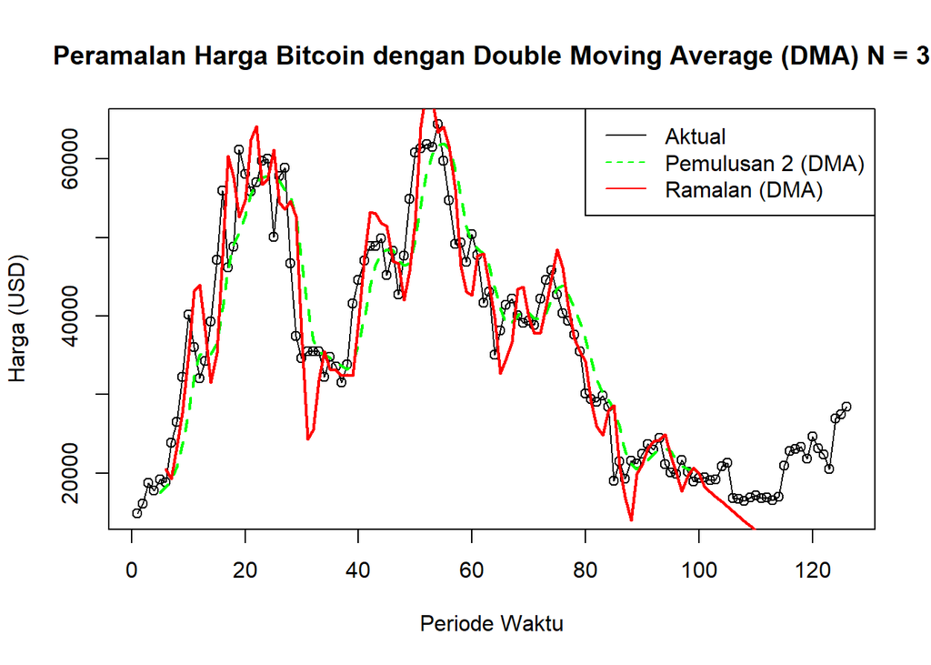

```r
# Plot hasil peramalan DMA
ts.plot(data_subset.ts, xlab = "Periode Waktu", ylab = "Harga (USD)", main = "Peramalan Harga Bitcoin dengan Double Moving Average (DMA) N = 3")
points(data_subset.ts)
lines(data.gab2[,3], col = "green", lty = 2, lwd = 2) # Pemulusan 2
lines(data.gab2[,6], col = "red", lty = 1, lwd = 2)  # Ramalan
legend("topright", legend = c("Aktual", "Pemulusan 2 (DMA)", "Ramalan (DMA)"), col = c("black", "green", "red"), lty = c(1, 2, 1))
```

Selanjutnya perhitungan akurasi dilakukan dengan ukuran akurasi *Sum Squares Error* (SSE), *Mean Square Error* (MSE) dan *Mean Absolute Percentage Error* (MAPE). Perhitungan akurasi dilakukan baik pada data latih maupun pada data uji.

### **Akurasi Data Latih**

```r
# Menghitung nilai keakuratan data latih
error_train.dma <- train_ma.ts - data_subset_ramal.dma[1:length(train_ma.ts)]
SSE_train.dma <- sum(error_train.dma[6:length(train_ma.ts)]^2)
MSE_train.dma <- mean(error_train.dma[6:length(train_ma.ts)]^2)
MAPE_train.dma <- mean(abs(error_train.dma[6:length(train_ma.ts)] / train_ma.ts[6:length(train_ma.ts)]) * 100)
akurasi_train.dma <- matrix(c(SSE = SSE_train.dma, MSE = MSE_train.dma, MAPE = MAPE_train.dma))
colnames(akurasi_train.dma) <- c("Akurasi m = 3")
rownames(akurasi_train.dma) <- c("SSE", "MSE", "MAPE")
akurasi_train.dma
```

```
##      Akurasi m = 3
## SSE   3.015408e+09
## MSE   3.174113e+07
## MAPE  1.146356e+01
```

### **Akurasi Data Uji**

```r
# Menghitung nilai keakuratan data uji
error_test.dma <- test_ma.ts - data.gab2[,6][(length(train_ma.ts)+1):length(data_subset.ts)]
SSE_test.dma <- sum(error_test.dma^2)
MSE_test.dma <- mean(error_test.dma^2)
MAPE_test.dma <- mean(abs(error_test.dma / test_ma.ts) * 100)
akurasi_test.dma <- matrix(c(SSE = SSE_test.dma, MSE = MSE_test.dma, MAPE = MAPE_test.dma))
colnames(akurasi_test.dma) <- c("Akurasi m = 3")
rownames(akurasi_test.dma) <- c("SSE", "MSE", "MAPE")
akurasi_test.dma
```

```
##      Akurasi m = 3
## SSE   4.200124e+09
## MSE   1.615432e+08
## MAPE  4.528867e+01
```

## **Perbandingan SMA dan DMA**

```r
MAPE_test.Full <- matrix(c(
  MAPE_train.sma,
  MAPE_train.dma,
  MAPE_test.sma,
  MAPE_test.dma
))
colnames(MAPE_test.Full) <- c("MAPE")
rownames(MAPE_test.Full) <- c("MAPE Data Latih SMA", "MAPE Data Latih DMA", "MAPE Data Uji SMA", "MAPE Data Uji DMA")
MAPE_test.Full
```

```
##                         MAPE
## MAPE Data Latih SMA 10.59678
## MAPE Data Latih DMA 11.46356
## MAPE Data Uji SMA   14.24379
## MAPE Data Uji DMA   45.28867
```

Berdasarkan data yang diberikan, model **Single Moving Average (SMA)** menunjukkan performa yang lebih konsisten dibandingkan **Double Moving Average (DMA)**. Pada **data latih**, SMA memiliki MAPE (Mean Absolute Percentage Error) sebesar **10.60%**, yang sedikit lebih baik dari DMA dengan 11.46%. Perbedaan paling signifikan terlihat pada **data uji**, di mana akurasi SMA menurun menjadi **14.24%**, sementara akurasi DMA anjlok drastis ke **45.29%**, menandakan bahwa model DMA gagal total dalam memprediksi data baru, kemungkinan karena volatilitas data yang tidak dapat ditangkap oleh asumsi tren linear yang digunakan.

## **Single Exponential Smoothing & Double Exponential Smoothing**

### **Pembagian Data**

Pembagian data latih dan data uji dilakukan dengan perbandingan 80% data latih dan 20% data uji.

```r
# Hitung jumlah data
n <- length(data_subset.ts)
n_train <- floor(0.8 * n)

# bagi data
training_es <- data_subset[1:n_train, ]
testing_es <- data_subset[(n_train + 1):n, ]

# Bagi data menggunakan fungsi 'window' untuk memastikan keselarasan waktu
train_es.ts <- window(data_subset.ts, end = time(data_subset.ts)[n_train])
test_es.ts <- window(data_subset.ts, start = time(data_subset.ts)[n_train + 1])
```

### **Eksplorasi**

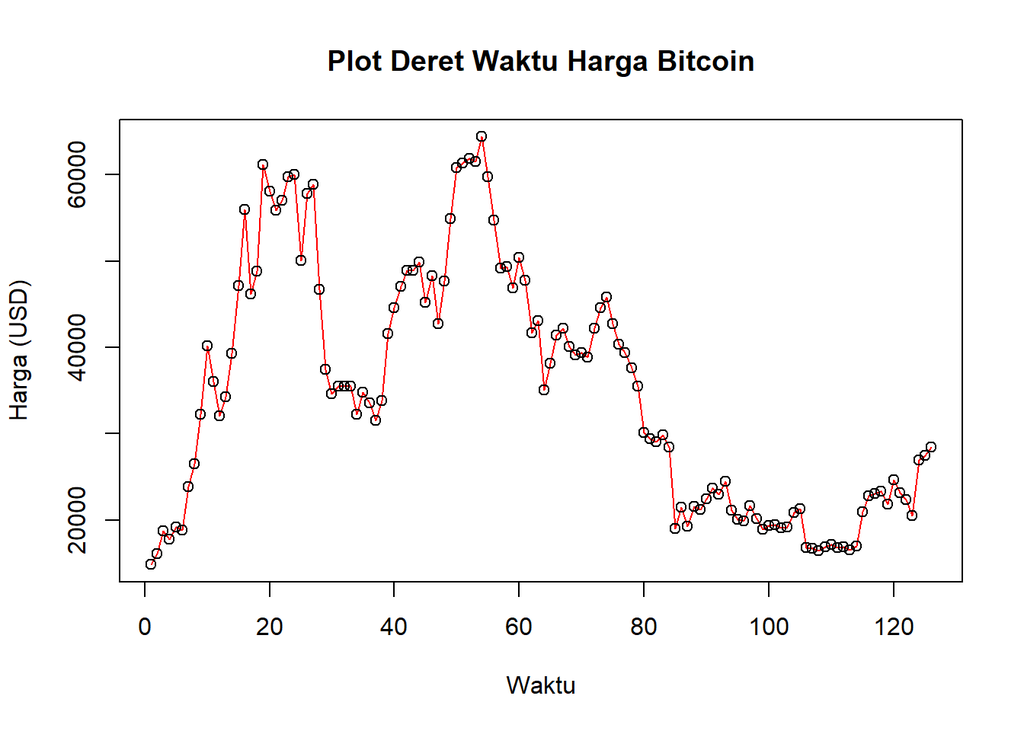

```r
# Eksplorasi keseluruhan data
plot(data_subset.ts, main = "Plot Deret Waktu Harga Bitcoin",
     xlab = "Waktu", ylab = "Harga (USD)", col = "red")
points(data_subset.ts)
```

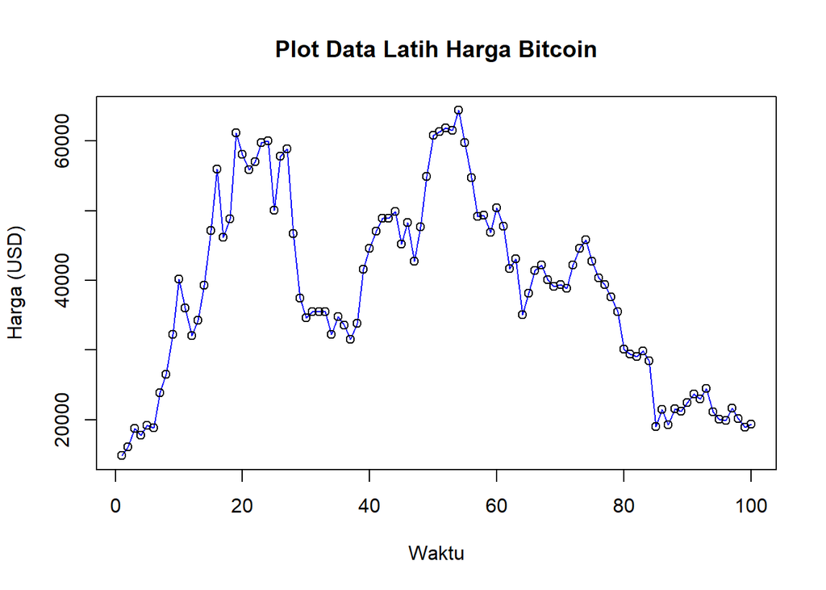

```r
# Eksplorasi data latih
plot(train_es.ts, main = "Plot Data Latih Harga Bitcoin",
     xlab = "Waktu", ylab = "Harga (USD)", col = "blue")
points(train_es.ts)
```

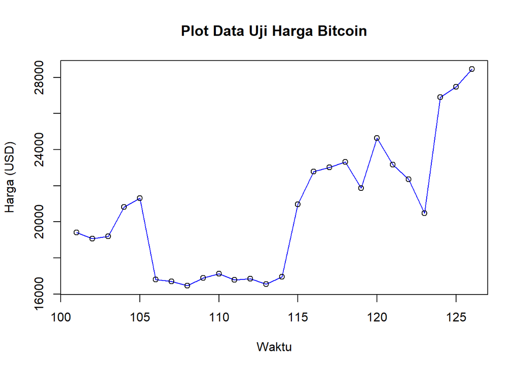

```r
# Eksplorasi data uji
plot(test_es.ts, main = "Plot Data Uji Harga Bitcoin",
     xlab = "Waktu", ylab = "Harga (USD)", col = "blue")
points(test_es.ts)
```

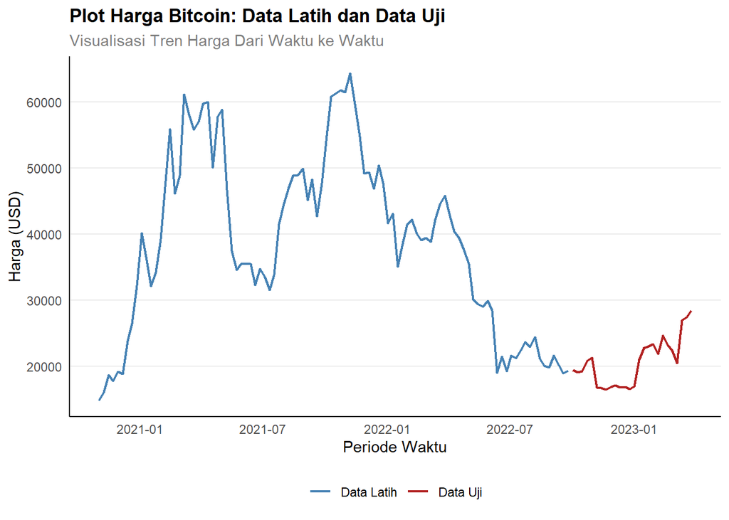

```r
library(ggplot2)
ggplot() +
  geom_line(data = training_es, aes(x = Date, y = Price, col = "Data Latih"), linewidth = 0.8) +
  geom_line(data = testing_es, aes(x = Date, y = Price, col = "Data Uji"), linewidth = 0.8) +
  labs(title = "Plot Harga Bitcoin: Data Latih dan Data Uji",
       subtitle = "Visualisasi Tren Harga Dari Waktu ke Waktu",
       x = "Periode Waktu",
       y = "Harga (USD)",
       color = "Keterangan") +
  scale_colour_manual(name = "Keterangan:",
                      values = c("Data Latih" = "steelblue", "Data Uji" = "firebrick")) +
  theme_minimal() +
  theme(
    legend.position = "bottom",
    legend.title = element_blank(), # Hilangkan judul legend agar lebih minimalis
    plot.title = element_text(face = "bold"),
    plot.subtitle = element_text(color = "gray50"),
    panel.grid.minor = element_blank(),
    panel.grid.major.x = element_blank(), # Hilangkan grid vertikal
    axis.line = element_line(color = "black")
  )
```

## **Single Exponential Smoothing (SES)**

Single Exponential Smoothing (SES) adalah metode peramalan deret waktu yang dikembangkan untuk mengatasi kelemahan Moving Average. Jika pada Moving Average setiap data periode sebelumnya dianggap memiliki bobot yang sama, maka SES memberikan bobot yang semakin mengecil secara eksponensial terhadap data lama, sehingga data terbaru diberi bobot lebih besar.

Single Exponential Smoothing merupakan metode pemulusan yang tepat digunakan untuk data dengan pola stasioner atau konstan.

Nilai pemulusan pada periode ke-t didapat dari persamaan:

$$\tilde{y}_T=\lambda
y_t+(1-\lambda)\tilde{y}_{T-1}$$

Nilai parameter $\lambda$ adalah nilai antara 0 dan 1.

Nilai pemulusan periode ke-t bertindak sebagai nilai ramalan pada periode ke-$(T+\tau)$.

$$\tilde{y}_{T+\tau}(T)=\tilde{y}_T$$

Pemulusan dengan metode SES dapat dilakukan dengan dua fungsi dari *packages* berbeda, yaitu (1) fungsi `ses()` dari *packages* `forecast` dan (2) fungsi `HoltWinters` dari *packages* `stats` .

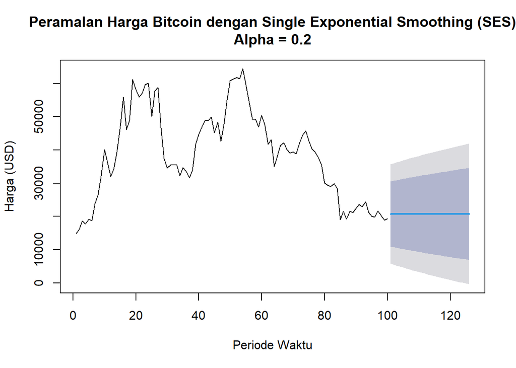

```r
# Cara 1 (fungsi SES)
# Untuk nilai alpha 0.2
data_subset.ses1 <- ses(train_es.ts, alpha = 0.2, h = 26)
plot(data_subset.ses1, main = "Peramalan Harga Bitcoin dengan Single Exponential Smoothing (SES)\nAlpha = 0.2", xlab = "Periode Waktu", ylab = "Harga (USD)")
```

```r
data_subset.ses1
```

```
##     Point Forecast     Lo 80    Hi 80      Lo 95    Hi 95
## 101       20754.92 10973.082 30536.75 5794.89275 35714.94
## 102       20754.92 10779.364 30730.47 5498.62592 36011.20
## 103       20754.92 10589.336 30920.49 5208.00382 36301.83
## 104       20754.92 10402.796 31107.03 4922.71559 36587.12
## 105       20754.92 10219.559 31290.27 4642.47791 36867.35
## 106       20754.92 10039.454 31470.38 4367.03167 37142.80
## 107       20754.92  9862.327 31647.50 4096.13921 37413.69
## 108       20754.92  9688.035 31821.80 3829.58187 37680.25
## 109       20754.92  9516.445 31993.39 3567.15795 37942.67
## 110       20754.92  9347.436 32162.39 3308.68092 38201.15
## 111       20754.92  9180.894 32328.94 3053.97790 38455.85
## 112       20754.92  9016.716 32493.11 2802.88823 38706.94
## 113       20754.92  8854.802 32655.03 2555.26237 38954.57
## 114       20754.92  8695.062 32814.77 2310.96079 39198.87
## 115       20754.92  8537.410 32972.42 2069.85311 39439.98
## 116       20754.92  8381.767 33128.06 1831.81724 39678.01
## 117       20754.92  8228.057 33281.77 1596.73869 39913.09
## 118       20754.92  8076.211 33433.62 1364.50989 40145.32
## 119       20754.92  7926.162 33583.67 1135.02964 40374.80
## 120       20754.92  7777.847 33731.98  908.20262 40601.63
## 121       20754.92  7631.209 33878.62  683.93886 40825.89
## 122       20754.92  7486.192 34023.64  462.15338 41047.68
## 123       20754.92  7342.742 34167.09  242.76580 41267.06
## 124       20754.92  7200.810 34309.02   25.69997 41484.13
## 125       20754.92  7060.349 34449.48 -189.11629 41698.95
## 126       20754.92  6921.314 34588.52 -401.75151 41911.58
```

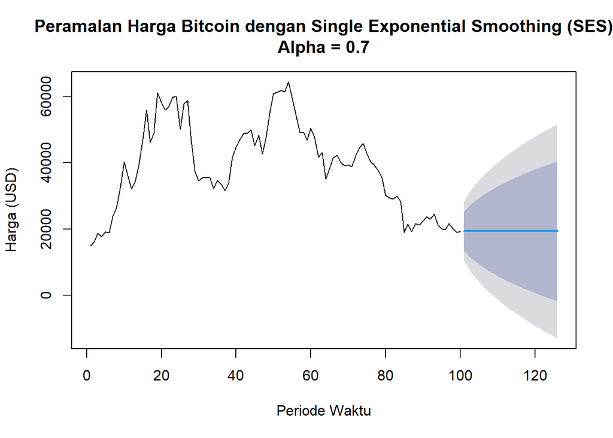

```r
# Untuk nilai alpha 0.7
data_subset.ses2 <- ses(train_es.ts, alpha = 0.7, h = 26)
plot(data_subset.ses2, main = "Peramalan Harga Bitcoin dengan Single Exponential Smoothing (SES)\nAlpha = 0.7", xlab = "Periode Waktu", ylab = "Harga (USD)")
```

```r
data_subset.ses2
```

```
##     Point Forecast      Lo 80    Hi 80       Lo 95    Hi 95
## 101       19331.53 13519.6382 25143.41  10443.0109 28220.04
## 102       19331.53 12237.2129 26425.84   8481.7106 30181.34
## 103       19331.53 11153.4751 27509.58   6824.2767 31838.77
## 104       19331.53 10197.4276 28465.62   5362.1282 33300.92
## 105       19331.53  9332.3764 29330.67   4039.1466 34623.90
## 106       19331.53  8536.4239 30126.63   2821.8422 35841.21
## 107       19331.53  7795.2585 30867.79   1688.3276 36974.72
## 108       19331.53  7098.9177 31564.13    623.3663 38039.68
## 109       19331.53  6440.1357 32222.92   -384.1538 39047.21
## 110       19331.53  5813.4203 32849.63  -1342.6323 40005.68
## 111       19331.53  5214.5002 33448.55  -2258.6017 40921.65
## 112       19331.53  4639.9755 34023.08  -3137.2613 41800.31
## 113       19331.53  4087.0879 34575.96  -3982.8300 42645.88
## 114       19331.53  3553.5625 35109.49  -4798.7866 43461.84
## 115       19331.53  3037.4974 35625.55  -5588.0401 44251.09
## 116       19331.53  2537.2827 36125.77  -6353.0524 45016.10
## 117       19331.53  2051.5421 36611.51  -7095.9286 45758.98
## 118       19331.53  1579.0872 37083.96  -7818.4860 46481.54
## 119       19331.53  1118.8843 37544.17  -8522.3057 47185.36
## 120       19331.53   670.0267 37993.02  -9208.7741 47871.83
## 121       19331.53   231.7146 38431.34  -9879.1145 48542.17
## 122       19331.53  -196.7620 38859.81 -10534.4130 49197.46
## 123       19331.53  -616.0370 39279.09 -11175.6388 49838.69
## 124       19331.53 -1026.6789 39689.73 -11803.6614 50466.71
## 125       19331.53 -1429.2000 40092.25 -12419.2643 51082.32
## 126       19331.53 -1824.0639 40487.12 -13023.1564 51686.21
```

Pada fungsi `ses()` , terdapat beberapa argumen yang umum digunakan, yaitu

- `y` : nilai data deret waktu
- `alpha` : parameter pemulusan utama (0–1), mengatur bobot data terbaru vs data lama.
- `beta` : parameter pemulusan tren.
- `gamma` : parameter pemulusan musiman.
- `h` : jumlah periode ke depan yang ingin diramalkan (forecast horizon).

  Kasus di atas merupakan contoh inisialisasi nilai parameter $\lambda$ dengan nilai `alpha` 0,2 dan 0,7 dan banyak periode data yang akan diramalkan adalah sebanyak 26 periode.

Untuk mendapatkan gambar hasil pemulusan pada data latih dengan fungsi `ses()` , perlu digunakan fungsi `autoplot()` dan `autolayer()` dari *library packages* `ggplot2` .

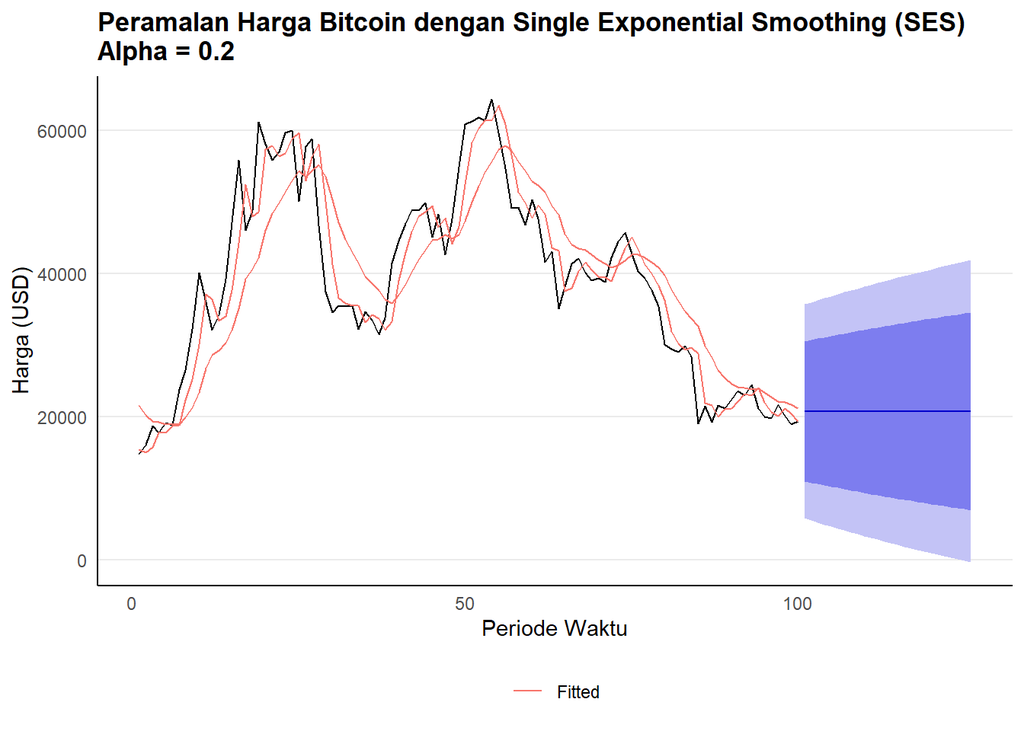

```r
autoplot(data_subset.ses1) +
  autolayer(data_subset.ses1$fitted, series="Fitted", PI=FALSE) +
  autolayer(data_subset.ses2$fitted, series="Fitted", PI=FALSE) +
  xlab("Periode Waktu") + ylab("Harga (USD)") +
  ggtitle("Peramalan Harga Bitcoin dengan Single Exponential Smoothing (SES)\nAlpha = 0.2") +
  guides(colour=guide_legend(title=" ")) +
  theme_minimal() +
  theme(
    legend.position = "bottom",
    legend.title = element_blank(),
    plot.title = element_text(face = "bold"),
    plot.subtitle = element_text(color = "gray50"),
    panel.grid.minor = element_blank(),
    panel.grid.major.x = element_blank(),
    axis.line = element_line(color = "black")
  )
```

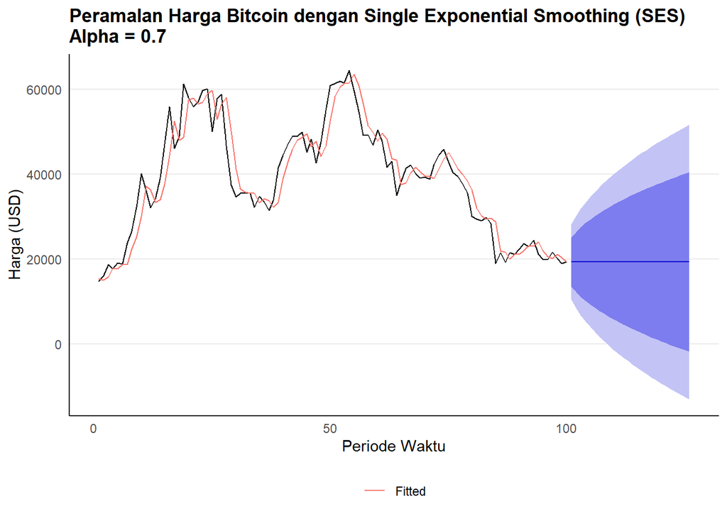

```r
autoplot(data_subset.ses2) +
  autolayer(data_subset.ses2$fitted, series="Fitted", PI=FALSE) +
  xlab("Periode Waktu") + ylab("Harga (USD)") +
  ggtitle("Peramalan Harga Bitcoin dengan Single Exponential Smoothing (SES)\nAlpha = 0.7") +
  guides(colour=guide_legend(title=" ")) +
  theme_minimal() +
  theme(
    legend.position = "bottom",
    legend.title = element_blank(), # Hilangkan judul legend agar lebih minimalis
    plot.title = element_text(face = "bold"),
    plot.subtitle = element_text(color = "gray50"),
    panel.grid.minor = element_blank(),
    panel.grid.major.x = element_blank(), # Hilangkan grid vertikal
    axis.line = element_line(color = "black")
  )
```

Selanjutnya akan digunakan fungsi `HoltWinters()` dengan nilai inisialisasi parameter dan panjang periode peramalan yang sama dengan fungsi `ses()`.

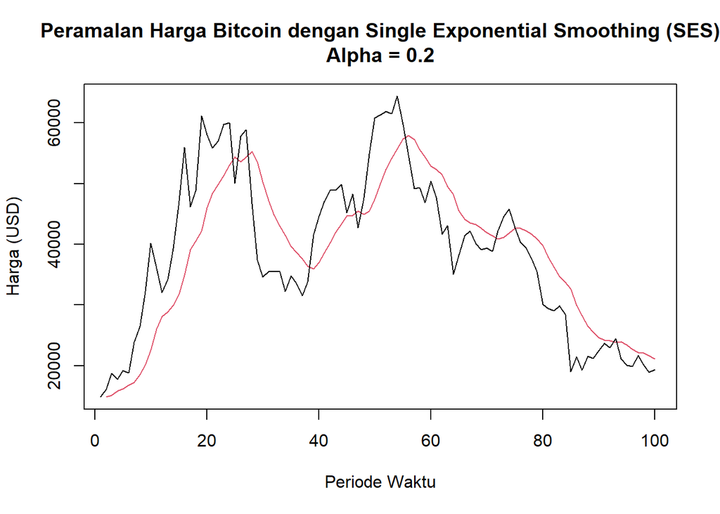

```r
# Cara 2 (fungsi HoltWinters)
# Untuk nilai alpha 0.2
data_subset.ses3 <- HoltWinters(train_es.ts, alpha = 0.2, beta = FALSE, gamma = FALSE)
plot(data_subset.ses3, main = "Peramalan Harga Bitcoin dengan Single Exponential Smoothing (SES)\nAlpha = 0.2", xlab = "Periode Waktu", ylab = "Harga (USD)")
```

```r
# Ramalan 26 periode ke depan
data_subset.ramal.ses3 <- forecast(data_subset.ses3, h = 26)
data_subset.ramal.ses3
```

```
##     Point Forecast     Lo 80    Hi 80      Lo 95    Hi 95
## 101       20754.92 10872.725 30637.11 5641.40999 35868.42
## 102       20754.92 10677.019 30832.81 5342.10360 36167.73
## 103       20754.92 10485.042 31024.79 5048.49985 36461.33
## 104       20754.92 10296.589 31213.24 4760.28470 36749.55
## 105       20754.92 10111.471 31398.36 4477.17192 37032.66
## 106       20754.92  9929.519 31580.31 4198.89973 37310.93
## 107       20754.92  9750.574 31759.26 3925.22804 37584.60
## 108       20754.92  9574.494 31935.34 3655.93595 37853.89
## 109       20754.92  9401.143 32108.69 3390.81968 38119.01
## 110       20754.92  9230.400 32279.43 3129.69081 38380.14
## 111       20754.92  9062.150 32447.68 2872.37465 38637.46
## 112       20754.92  8896.287 32613.54 2618.70892 38891.12
## 113       20754.92  8732.712 32777.12 2368.54253 39141.29
## 114       20754.92  8571.333 32938.50 2121.73454 39388.10
## 115       20754.92  8412.064 33097.77 1878.15321 39631.68
## 116       20754.92  8254.824 33255.01 1637.67520 39872.16
## 117       20754.92  8099.537 33410.29 1400.18485 40109.65
## 118       20754.92  7946.133 33563.70 1165.57349 40344.26
## 119       20754.92  7794.545 33715.29  933.73889 40576.09
## 120       20754.92  7644.709 33865.12  704.58473 40805.25
## 121       20754.92  7496.566 34013.26  478.02013 41031.81
## 122       20754.92  7350.061 34159.77  253.95924 41255.87
## 123       20754.92  7205.139 34304.69   32.32084 41477.51
## 124       20754.92  7061.751 34448.08 -186.97198 41696.80
## 125       20754.92  6919.849 34589.98 -403.99215 41913.82
## 126       20754.92  6779.388 34730.44 -618.80890 42128.64
```

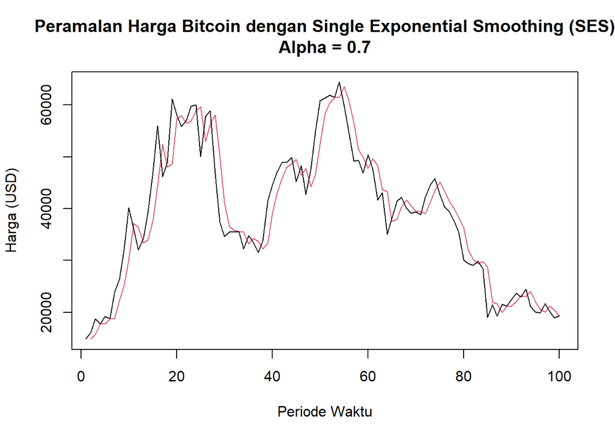

```r
# Untuk nilai alpha 0.7
data_subset.ses4 <- HoltWinters(train_es.ts, alpha = 0.7, beta = FALSE, gamma = FALSE)
plot(data_subset.ses4, main = "Peramalan Harga Bitcoin dengan Single Exponential Smoothing (SES)\nAlpha = 0.7", xlab = "Periode Waktu", ylab = "Harga (USD)")
```

```r
# Ramalan 26 periode ke depan
data_subset.ramal.ses4 <- forecast(data_subset.ses4, h = 26)
data_subset.ramal.ses4
```

```
##     Point Forecast      Lo 80    Hi 80       Lo 95    Hi 95
## 101       19331.53 13519.6747 25143.38  10443.0667 28219.98
## 102       19331.53 12237.2575 26425.79   8481.7788 30181.27
## 103       19331.53 11153.5265 27509.52   6824.3552 31838.70
## 104       19331.53 10197.4849 28465.57   5362.2159 33300.84
## 105       19331.53  9332.4392 29330.61   4039.2426 34623.81
## 106       19331.53  8536.4916 30126.56   2821.9459 35841.11
## 107       19331.53  7795.3309 30867.72   1688.4384 36974.61
## 108       19331.53  7098.9945 31564.06    623.4837 38039.57
## 109       19331.53  6440.2167 32222.83   -384.0301 39047.08
## 110       19331.53  5813.5052 32849.55  -1342.5025 40005.55
## 111       19331.53  5214.5888 33448.46  -2258.4661 40921.52
## 112       19331.53  4640.0677 34022.98  -3137.1203 41800.17
## 113       19331.53  4087.1836 34575.87  -3982.6836 42645.73
## 114       19331.53  3553.6616 35109.39  -4798.6351 43461.69
## 115       19331.53  3037.5997 35625.45  -5587.8837 44250.93
## 116       19331.53  2537.3882 36125.66  -6352.8912 45015.94
## 117       19331.53  2051.6506 36611.40  -7095.7627 45758.81
## 118       19331.53  1579.1987 37083.85  -7818.3155 46481.37
## 119       19331.53  1118.9986 37544.05  -8522.1308 47185.18
## 120       19331.53   670.1438 37992.91  -9208.5949 47871.65
## 121       19331.53   231.8345 38431.22  -9878.9312 48541.98
## 122       19331.53  -196.6394 38859.69 -10534.2255 49197.28
## 123       19331.53  -615.9118 39278.96 -11175.4473 49838.50
## 124       19331.53 -1026.5511 39689.60 -11803.4659 50466.52
## 125       19331.53 -1429.0697 40092.12 -12419.0650 51082.12
## 126       19331.53 -1823.9310 40486.98 -13022.9533 51686.00
```

Fungsi `HoltWinters` memiliki argumen yang sama dengan fungsi `ses()`. Argumen-argumen kedua fungsi dapat dilihat lebih lanjut dengan `?ses()` atau `?HoltWinters`.

Nilai parameter $\alpha$ dari kedua fungsi dapat dioptimalkan menyesuaikan dari *error*-nya paling minimumnya. Caranya adalah dengan membuat parameter $\alpha =$ `NULL`.

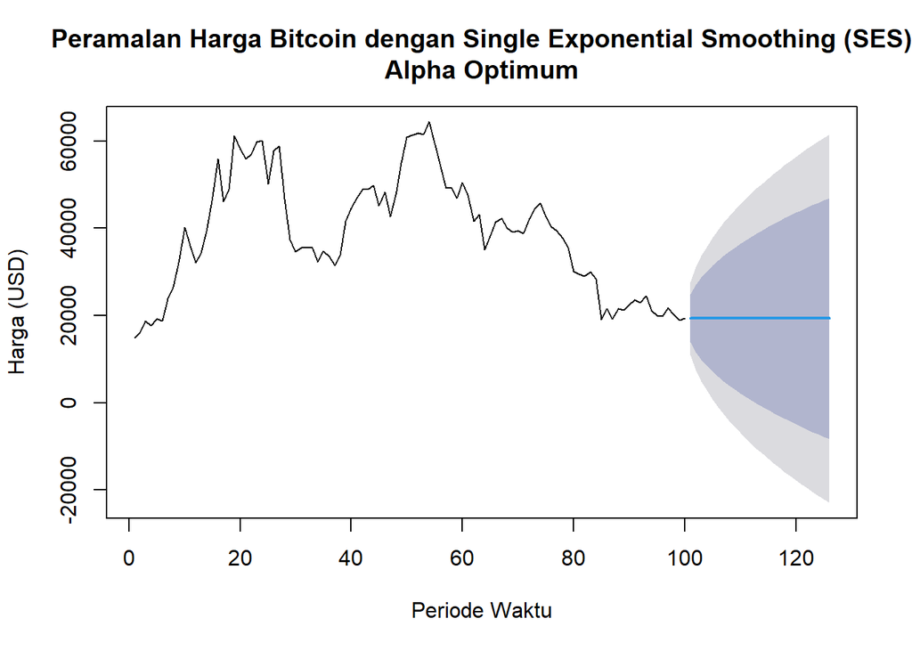

```r
# Mencari nilai alpha optimum
# SES
data_subset.ses_opt <- ses(train_es.ts, h = 26, initial = "optimal", alpha = NULL)
plot(data_subset.ses_opt, main = "Peramalan Harga Bitcoin dengan Single Exponential Smoothing (SES)\nAlpha Optimum", xlab = "Periode Waktu", ylab = "Harga (USD)")
```

```r
data_subset.ses_opt
```

```
##     Point Forecast      Lo 80    Hi 80       Lo 95    Hi 95
## 101       19311.86 13891.0213 24732.70  11021.4019 27602.32
## 102       19311.86 11646.0198 26977.70   7587.9684 31035.75
## 103       19311.86  9923.3180 28700.40   4953.3234 33670.40
## 104       19311.86  8470.9958 30152.73   2732.1883 35891.53
## 105       19311.86  7191.4659 31432.26    775.3162 37848.41
## 106       19311.86  6034.6777 32589.04   -993.8387 39617.56
## 107       19311.86  4970.8982 33652.82  -2620.7491 41244.47
## 108       19311.86  3980.7543 34642.97  -4135.0435 42758.77
## 109       19311.86  3050.7893 35572.93  -5557.3022 44181.02
## 110       19311.86  2171.2055 36452.52  -6902.5096 45526.23
## 111       19311.86  1334.6062 37289.12  -8181.9778 46805.70
## 112       19311.86   535.2450 38088.48  -9404.4953 48028.22
## 113       19311.86  -231.4480 38855.17 -10577.0510 49200.77
## 114       19311.86  -969.1781 39592.90 -11705.3118 50329.03
## 115       19311.86 -1680.9989 40304.72 -12793.9478 51417.67
## 116       19311.86 -2369.4624 40993.18 -13846.8619 52470.58
## 117       19311.86 -3036.7274 41660.45 -14867.3556 53491.08
## 118       19311.86 -3684.6392 42308.36 -15858.2512 54481.97
## 119       19311.86 -4314.7901 42938.51 -16821.9838 55445.71
## 120       19311.86 -4928.5652 43552.29 -17760.6718 56384.39
## 121       19311.86 -5527.1784 44150.90 -18676.1718 57299.89
## 122       19311.86 -6111.7009 44735.42 -19570.1217 58193.84
## 123       19311.86 -6683.0831 45306.81 -20443.9754 59067.70
## 124       19311.86 -7242.1733 45865.90 -21299.0301 59922.75
## 125       19311.86 -7789.7322 46413.45 -22136.4492 60760.17
## 126       19311.86 -8326.4453 46950.17 -22957.2810 61581.00
```

```r
# Lambda optimum HoltWinters
data_subset.ses_opt2 <- HoltWinters(train_es.ts, beta = FALSE, gamma = FALSE)
data_subset.ses_opt2
```

```
## Holt-Winters exponential smoothing without trend and without seasonal component.
##
## Call:
## HoltWinters(x = train_es.ts, beta = FALSE, gamma = FALSE)
##
## Smoothing parameters:
##  alpha: 0.9999578
##  beta : FALSE
##  gamma: FALSE
##
## Coefficients:
##       [,1]
## a 19311.88
```

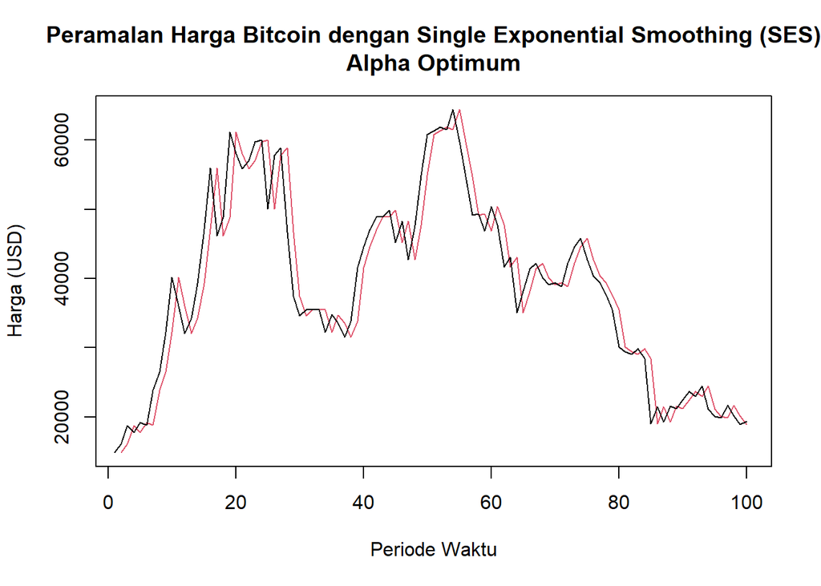

```r
plot(data_subset.ses_opt2, main = "Peramalan Harga Bitcoin dengan Single Exponential Smoothing (SES)\nAlpha Optimum", xlab = "Periode Waktu", ylab = "Harga (USD)")
```

```r
# Ramalan 26 periode ke depan
data_subset.ramal.ses_opt2 <- forecast(data_subset.ses_opt2, h = 26)
data_subset.ramal.ses_opt2
```

```
##     Point Forecast      Lo 80    Hi 80       Lo 95    Hi 95
## 101       19311.88 13891.3890 24732.38  11021.9524 27601.81
## 102       19311.88 11646.3084 26977.46   7588.3980 31035.37
## 103       19311.88  9923.5758 28700.19   4953.7058 33670.06
## 104       19311.88  8471.2377 30152.53   2732.5463 35891.22
## 105       19311.88  7191.6986 31432.07    775.6601 37848.11
## 106       19311.88  6034.9048 32588.86   -993.5033 39617.27
## 107       19311.88  4971.1219 33652.65  -2620.4189 41244.19
## 108       19311.88  3980.9760 34642.79  -4134.7163 42758.48
## 109       19311.88  3051.0100 35572.76  -5556.9765 44180.74
## 110       19311.88  2171.4259 36452.34  -6902.1843 45525.95
## 111       19311.88  1334.8268 37288.94  -8181.6523 46805.42
## 112       19311.88   535.4662 38088.30  -9404.1689 48027.94
## 113       19311.88  -231.2260 38854.99 -10576.7233 49200.49
## 114       19311.88  -968.9550 39592.72 -11704.9825 50328.75
## 115       19311.88 -1680.7745 40304.54 -12793.6165 51417.38
## 116       19311.88 -2369.2367 40993.00 -13846.5285 52470.30
## 117       19311.88 -3036.5002 41660.27 -14867.0199 53490.79
## 118       19311.88 -3684.4104 42308.18 -15857.9131 54481.68
## 119       19311.88 -4314.5596 42938.33 -16821.6432 55445.41
## 120       19311.88 -4928.3330 43552.10 -17760.3286 56384.10
## 121       19311.88 -5526.9445 44150.71 -18675.8259 57299.59
## 122       19311.88 -6111.4652 44735.23 -19569.7731 58193.54
## 123       19311.88 -6682.8455 45306.61 -20443.6240 59067.39
## 124       19311.88 -7241.9339 45865.70 -21298.6758 59922.44
## 125       19311.88 -7789.4910 46413.26 -22136.0921 60759.86
## 126       19311.88 -8326.2022 46949.97 -22956.9211 61580.69
```

Setelah dilakukan peramalan, akan dilakukan perhitungan keakuratan hasil peramalan. Perhitungan akurasi ini dilakukan baik pada data latih dan data uji.

### **Akurasi Data Latih**

```r
# Keakuratan Metode
# Pada data training

# SES dengan alpha 0.2
SSE_train.ses1 <- data_subset.ses3$SSE
MSE_train.ses1 <- SSE_train.ses1 / length(train_es.ts)
RMSE_train.ses1 <- sqrt(MSE_train.ses1)
akurasi_train.ses1 <- matrix(c(SSE = SSE_train.ses1, MSE = MSE_train.ses1, RMSE = RMSE_train.ses1))
colnames(akurasi_train.ses1) <- c("Akurasi alpha = 0.2")
rownames(akurasi_train.ses1) <- c("SSE", "MSE", "RMSE")
akurasi_train.ses1
```

```
##      Akurasi alpha = 0.2
## SSE         5.836075e+09
## MSE         5.836075e+07
## RMSE        7.639421e+03
```

```r
# SES dengan alpha 0.7
SSE_train.ses2 <- data_subset.ses4$SSE
MSE_train.ses2 <- SSE_train.ses2 / length(train_es.ts)
RMSE_train.ses2 <- sqrt(MSE_train.ses2)
akurasi_train.ses2 <- matrix(c(SSE = SSE_train.ses2, MSE = MSE_train.ses2, RMSE = RMSE_train.ses2))
colnames(akurasi_train.ses2) <- c("Akurasi alpha = 0.7")
rownames(akurasi_train.ses2) <- c("SSE", "MSE", "RMSE")
akurasi_train.ses2
```

```
##      Akurasi alpha = 0.7
## SSE         2.015918e+09
## MSE         2.015918e+07
## RMSE        4.489898e+03
```

```r
# Cara manual
# SES dengan alpha 0.2
data_subset.fitted.ses1 <- data_subset.ramal.ses3$fitted
data_subset.sisaan1 <- data_subset.ramal.ses3$residuals
head(data_subset.sisaan1)
```

```
## Time Series:
## Start = 1
## End = 6
## Frequency = 1
## [1]       NA 1242.600 3610.280 1931.724 2961.179 2031.343
```

```r
data_subset.resid1 <- training_es$Price - data_subset.ramal.ses3$fitted
head(data_subset.resid1)
```

```
## Time Series:
## Start = 1
## End = 6
## Frequency = 1
## [1]       NA 1242.600 3610.280 1931.724 2961.179 2031.343
```

```r
SSE_train.ses1_manual <- sum(data_subset.sisaan1[2:length(train_es.ts)]^2)
SSE_train.ses1_manual
```

```
## [1] 5836074671
```

```r
MSE_train.ses1_manual <- SSE_train.ses1_manual / length(train_es.ts)
MSE_train.ses1_manual
```

```
## [1] 58360747
```

```r
MAPE_train.ses1_manual <- sum(abs(data_subset.sisaan1[2:length(train_es.ts)] / train_es.ts[2:length(train_es.ts)]) * 100) / length(train_es.ts)
MAPE_train.ses1_manual
```

```
## [1] 16.83116
```

```r
akurasi_train.ses1_manual <- matrix(c(SSE = SSE_train.ses1_manual, MSE = MSE_train.ses1_manual, MAPE = MAPE_train.ses1_manual))
colnames(akurasi_train.ses1_manual) <- c("Akurasi alpha = 0.2")
rownames(akurasi_train.ses1_manual) <- c("SSE", "MSE", "MAPE")
akurasi_train.ses1_manual
```

```
##      Akurasi alpha = 0.2
## SSE         5.836075e+09
## MSE         5.836075e+07
## MAPE        1.683116e+01
```

```r
# SES dengan alpha 0.7
data_subset.fitted.ses2 <- data_subset.ramal.ses4$fitted
data_subset.sisaan2 <- data_subset.ramal.ses4$residuals
head(data_subset.sisaan2)
```

```
## Time Series:
## Start = 1
## End = 6
## Frequency = 1
## [1]         NA 1242.60000 2988.98000  -59.80600 1397.85820   81.75746
```

```r
data_subset.resid2 <- training_es$Price - data_subset.ramal.ses4$fitted
head(data_subset.resid2)
```

```
## Time Series:
## Start = 1
## End = 6
## Frequency = 1
## [1]         NA 1242.60000 2988.98000  -59.80600 1397.85820   81.75746
```

```r
SSE_train.ses2_manual <- sum(data_subset.sisaan2[2:length(train_es.ts)]^2)
SSE_train.ses2_manual
```

```
## [1] 2015918166
```

```r
MSE_train.ses2_manual <- SSE_train.ses2_manual / length(train_es.ts)
MSE_train.ses2_manual
```

```
## [1] 20159182
```

```r
MAPE_train.ses2_manual <- sum(abs(data_subset.sisaan2[2:length(train_es.ts)] / train_es.ts[2:length(train_es.ts)]) * 100) / length(train_es.ts)
MAPE_train.ses2_manual
```

```
## [1] 8.548767
```

```r
akurasi_train.ses2_manual <- matrix(c(SSE = SSE_train.ses2_manual, MSE = MSE_train.ses2_manual, MAPE = MAPE_train.ses2_manual))
colnames(akurasi_train.ses2_manual) <- c("Akurasi alpha = 0.7")
rownames(akurasi_train.ses2_manual) <- c("SSE", "MSE", "MAPE")
akurasi_train.ses2_manual
```

```
##      Akurasi alpha = 0.7
## SSE         2.015918e+09
## MSE         2.015918e+07
## MAPE        8.548767e+00
```

### **Akurasi Data Uji**

```r
# Jumlah data uji
n_test <- length(test_es.ts)

# error (ramalan - aktual), samakan panjang dan tipe numeric
error_test.ses1 <- as.numeric(data_subset.ramal.ses3$mean)[1:n_test] - as.numeric(test_es.ts)
error_test.ses2 <- as.numeric(data_subset.ramal.ses4$mean)[1:n_test] - as.numeric(test_es.ts)
error_test.ses_opt <- as.numeric(data_subset.ramal.ses_opt2$mean)[1:n_test] - as.numeric(test_es.ts)

# SSE / MSE / RMSE / MAPE untuk masing-masing model (abaikan NA)
SSE_test.ses1 <- sum(error_test.ses1^2, na.rm = TRUE)
MSE_test.ses1 <- mean(error_test.ses1^2, na.rm = TRUE)
RMSE_test.ses1 <- sqrt(MSE_test.ses1)
MAPE_test.ses1 <- mean(abs(error_test.ses1 / test_es.ts) * 100, na.rm = TRUE)

SSE_test.ses2 <- sum(error_test.ses2^2, na.rm = TRUE)
MSE_test.ses2 <- mean(error_test.ses2^2, na.rm = TRUE)
RMSE_test.ses2 <- sqrt(MSE_test.ses2)
MAPE_test.ses2 <- mean(abs(error_test.ses2 / test_es.ts) * 100, na.rm = TRUE)

SSE_test.ses_opt <- sum(error_test.ses_opt^2, na.rm = TRUE)
MSE_test.ses_opt <- mean(error_test.ses_opt^2, na.rm = TRUE)
RMSE_test.ses_opt <- sqrt(MSE_test.ses_opt)
MAPE_test.ses_opt <- mean(abs(error_test.ses_opt / test_es.ts) * 100, na.rm = TRUE)

# Tabel akurasi
akurasi_test.ses <- rbind(
  c(SSE = SSE_test.ses1, MSE = MSE_test.ses1, RMSE = RMSE_test.ses1, MAPE = MAPE_test.ses1),
  c(SSE = SSE_test.ses2, MSE = MSE_test.ses2, RMSE = RMSE_test.ses2, MAPE = MAPE_test.ses2),
  c(SSE = SSE_test.ses_opt, MSE = MSE_test.ses_opt, RMSE = RMSE_test.ses_opt, MAPE = MAPE_test.ses_opt)
)
colnames(akurasi_test.ses) <- c("SSE", "MSE", "RMSE", "MAPE")
rownames(akurasi_test.ses) <- c("Akurasi alpha = 0.2", "Akurasi alpha = 0.7", "Akurasi alpha optimum")
akurasi_test.ses
```

```
##                             SSE      MSE     RMSE     MAPE
## Akurasi alpha = 0.2   332554779 12790568 3576.390 14.79128
## Akurasi alpha = 0.7   375647528 14447982 3801.050 14.23689
## Akurasi alpha optimum 376979123 14499197 3807.781 14.23806
```

```r
accuracy(data_subset.ramal.ses3, test_es.ts)
```

```
##                     ME     RMSE      MAE       MPE     MAPE      MASE      ACF1
## Training set  299.3190 7677.907 6341.460 -2.111037 17.00117 2.0303180 0.8367098
## Test set     -129.4884 3576.390 2993.588 -3.538115 14.79128 0.9584443 0.7511095
##              Theil's U
## Training set        NA
## Test set      1.794649
```

```r
accuracy(data_subset.ramal.ses4, test_es.ts)
```

```
##                      ME     RMSE      MAE       MPE      MAPE     MASE
## Training set   64.98017 4512.517 3293.970 -0.495335  8.635119 1.054616
## Test set     1293.90133 3801.050 3087.392  3.562617 14.236892 0.988477
##                   ACF1 Theil's U
## Training set 0.3669507        NA
## Test set     0.7511095  1.738628
```

```r
accuracy(data_subset.ramal.ses_opt2, test_es.ts)
```

```
##                      ME     RMSE      MAE        MPE      MAPE      MASE
## Training set   45.28963 4208.462 3123.389 -0.3203764  8.280032 1.0000019
## Test set     1313.54325 3807.781 3090.414  3.6606028 14.238058 0.9894445
##                    ACF1 Theil's U
## Training set 0.09941549        NA
## Test set     0.75110950  1.739953
```

## **Double Exponential Smoothing (DES)**

Metode pemulusan *Double Exponential Smoothing* (DES) digunakan untuk data yang memiliki pola tren. Metode DES adalah metode semacam SES, hanya saja dilakukan dua kali, yaitu pertama untuk tahapan ‘level’ dan kedua untuk tahapan ‘tren’. Pemulusan menggunakan metode ini akan menghasilkan peramalan tidak konstan untuk periode berikutnya.

Pemulusan dengan metode DES kali ini akan menggunakan fungsi `HoltWinters()` . Jika sebelumnya nilai argumen `beta` dibuat `FALSE` , kali ini argumen tersebut akan diinisialisasi bersamaan dengan nilai `alpha` .

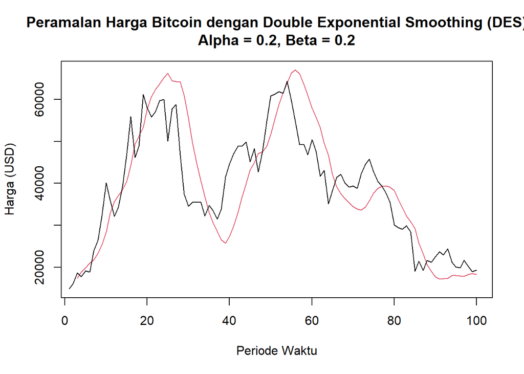

```r
# Alpha = 0.2 dan Beta = 0.2
data_subset.des1 <- HoltWinters(train_es.ts, alpha = 0.2, beta = 0.2, gamma = FALSE)
plot(data_subset.des1, main = "Peramalan Harga Bitcoin dengan Double Exponential Smoothing (DES)\nAlpha = 0.2, Beta = 0.2", xlab = "Periode Waktu", ylab = "Harga (USD)")
```

```r
# Ramalan 26 periode ke depan
data_subset.ramal.des1 <- forecast(data_subset.des1, h = 26)
data_subset.ramal.des1
```

```
##     Point Forecast       Lo 80    Hi 80       Lo 95    Hi 95
## 101       18352.17   7929.0288 28775.31   2411.3526 34292.98
## 102       18181.85   7462.7326 28900.98   1788.3720 34575.34
## 103       18011.54   6902.2176 29120.87   1021.2962 35001.79
## 104       17841.23   6242.0052 29440.46    101.7463 35580.71
## 105       17670.92   5479.8556 29861.98   -973.7030 36315.54
## 106       17500.61   4616.3249 30384.89  -2204.2014 37205.41
## 107       17330.29   3654.1190 31006.47  -3585.6104 38246.20
## 108       17159.98   2597.3982 31722.56  -5111.5675 39431.53
## 109       16989.67   1451.1500 32528.19  -6774.4450 40753.78
## 110       16819.36    220.6928 33418.02  -8566.1091 42204.82
## 111       16649.04  -1088.6752 34386.76 -10478.4568 43776.55
## 112       16478.73  -2471.8981 35429.36 -12503.7557 45461.22
## 113       16308.42  -3924.2854 36541.12 -14634.8325 47251.67
## 114       16138.11  -5441.5652 37717.78 -16865.1539 49141.37
## 115       15967.80  -7019.8925 38955.48 -19188.8393 51124.43
## 116       15797.48  -8655.8307 40250.80 -21600.6330 53195.60
## 117       15627.17 -10346.3199 41600.66 -24095.8553 55350.20
## 118       15456.86 -12088.6392 43002.36 -26670.3447 57584.06
## 119       15286.55 -13880.3678 44453.46 -29320.3994 59893.49
## 120       15116.23 -15719.3489 45951.82 -32042.7204 62275.19
## 121       14945.92 -17603.6557 47495.50 -34834.3611 64726.20
## 122       14775.61 -19531.5615 49082.78 -37692.6807 67243.90
## 123       14605.30 -21501.5137 50712.11 -40615.3047 69825.90
## 124       14434.98 -23512.1110 52382.08 -43600.0900 72470.06
## 125       14264.67 -25562.0836 54091.43 -46645.0948 75174.44
## 126       14094.36 -27650.2768 55839.00 -49748.5527 77937.27
```

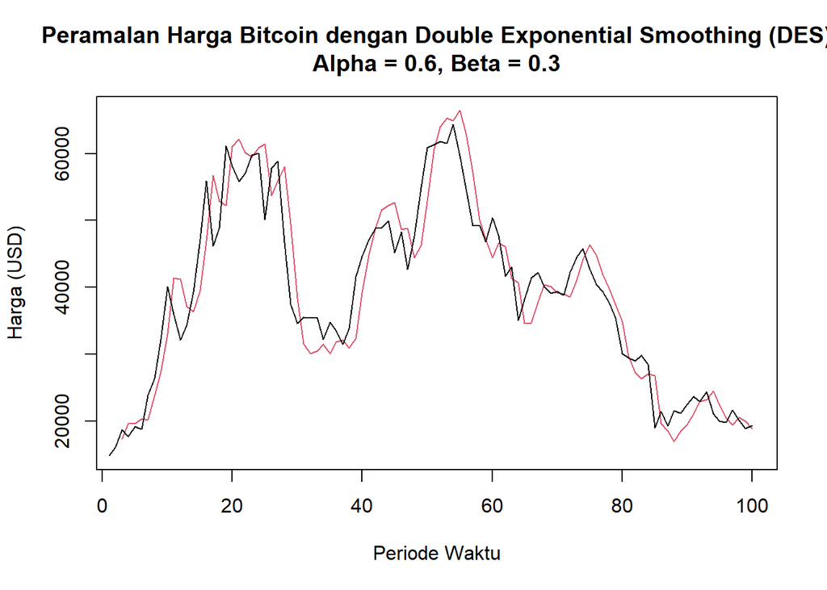

```r
# Alpha = 0.6 dan Beta = 0.3
data_subset.des2 <- HoltWinters(train_es.ts, alpha = 0.6, beta = 0.3, gamma = FALSE)
plot(data_subset.des2, main = "Peramalan Harga Bitcoin dengan Double Exponential Smoothing (DES)\nAlpha = 0.6, Beta = 0.3", xlab = "Periode Waktu", ylab = "Harga (USD)")
```

```r
# Ramalan 26 periode ke depan
data_subset.ramal.des2 <- forecast(data_subset.des2, h = 26)
data_subset.ramal.des2
```

```
##     Point Forecast       Lo 80     Hi 80        Lo 95     Hi 95
## 101      18714.101  12643.8041  24784.40    9430.3828  27997.82
## 102      18300.626  10602.1103  25999.14    6526.7623  30074.49
## 103      17887.151   8231.7515  27542.55    3120.4919  32653.81
## 104      17473.675   5594.4893  29352.86    -693.9718  35641.32
## 105      17060.200   2731.2115  31389.19   -4854.0966  38974.50
## 106      16646.724   -330.5857  33624.03   -9317.8306  42611.28
## 107      16233.249  -3571.5559  36038.05  -14055.5862  46522.08
## 108      15819.773  -6977.4063  38616.95  -19045.5041  50685.05
## 109      15406.298 -10537.1051  41349.70  -24270.7130  55083.31
## 110      14992.822 -14241.8207  44227.47  -29717.7059  59703.35
## 111      14579.347 -18084.2686  47242.96  -35375.3421  64534.04
## 112      14165.871 -22058.2946  50390.04  -41234.2097  69565.95
## 113      13752.396 -26158.5978  53663.39  -47286.2015  74790.99
## 114      13338.920 -30380.5398  57058.38  -53524.2240  80202.06
## 115      12925.445 -34720.0096  60570.90  -59941.9897  85792.88
## 116      12511.969 -39173.3245  64197.26  -66533.8664  91557.81
## 117      12098.494 -43737.1561  67934.14  -73294.7638  97491.75
## 118      11685.018 -48408.4730  71778.51  -80220.0458 103590.08
## 119      11271.543 -53184.4972  75727.58  -87305.4637 109848.55
## 120      10858.068 -58062.6680  79778.80  -94547.1015 116263.24
## 121      10444.592 -63040.6140  83929.80 -101941.3322 122830.52
## 122      10031.117 -68116.1295  88178.36 -109484.7827 129547.02
## 123       9617.641 -73287.1552  92522.44 -117174.3034 136409.59
## 124       9204.166 -78551.7621  96960.09 -125006.9441 143415.28
## 125       8790.690 -83908.1374 101489.52 -132979.9325 150561.31
## 126       8377.215 -89354.5733 106109.00 -141090.6568 157845.09
```

Selanjutnya jika ingin membandingkan plot data latih dan data uji adalah sebagai berikut.

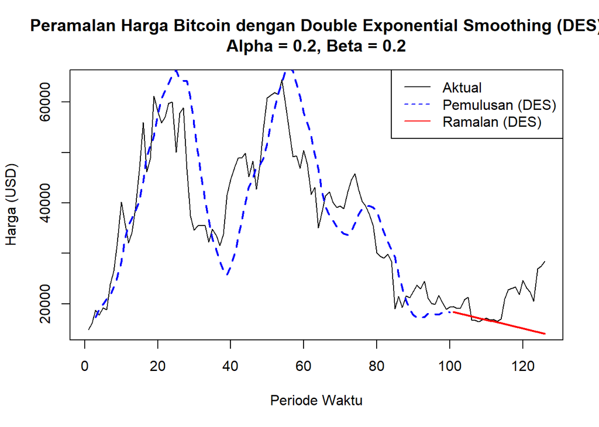

```r
plot(data_subset.ts, main = "Peramalan Harga Bitcoin dengan Double Exponential Smoothing (DES)\nAlpha = 0.2, Beta = 0.2", xlab = "Periode Waktu", ylab = "Harga (USD)")
lines(data_subset.ramal.des1$fitted, col = "blue", lty = 2, lwd = 2) # Pemulusan
lines(data_subset.ramal.des1$mean, col = "red", lty = 1, lwd = 2)  # Ramalan
legend("topright", legend = c("Aktual", "Pemulusan (DES)", "Ramalan (DES)"), col = c("black", "blue", "red"), lty = c(1, 2, 1))
```

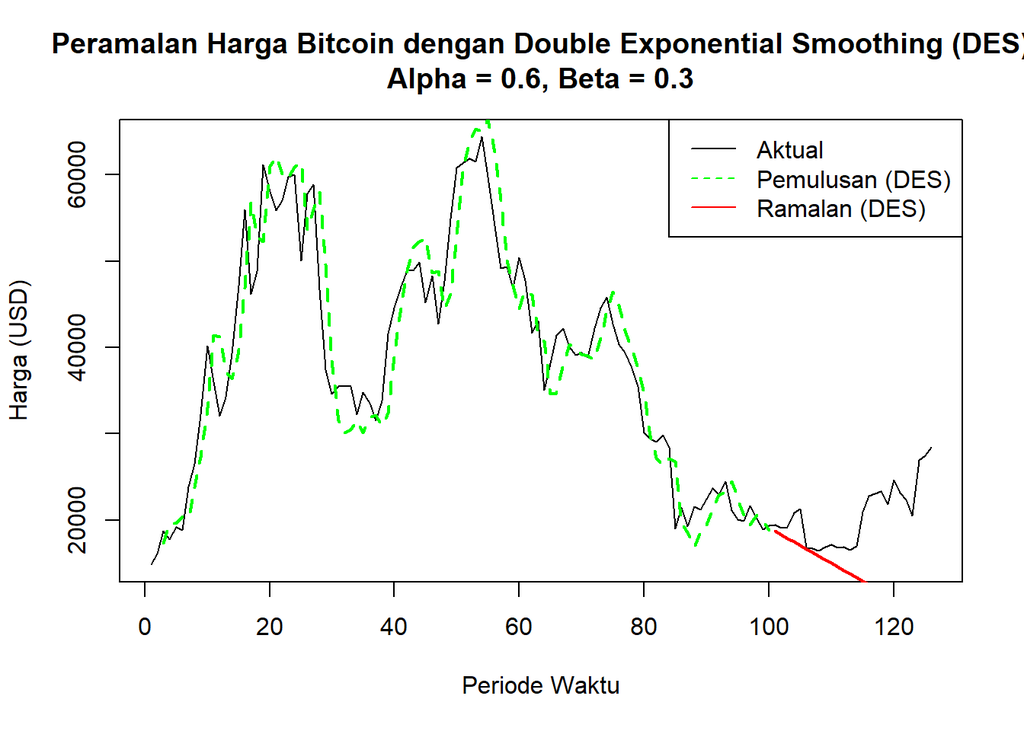

```r
plot(data_subset.ts, main = "Peramalan Harga Bitcoin dengan Double Exponential Smoothing (DES)\nAlpha = 0.6, Beta = 0.3", xlab = "Periode Waktu", ylab = "Harga (USD)")
lines(data_subset.ramal.des2$fitted, col = "green", lty = 2, lwd = 2) # Pemulusan
lines(data_subset.ramal.des2$mean, col = "red", lty = 1, lwd = 2)  # Ramalan
legend("topright", legend = c("Aktual", "Pemulusan (DES)", "Ramalan (DES)"), col = c("black", "green", "red"), lty = c(1, 2, 1))
```

Untuk mendapatkan nilai parameter optimum dari DES, argumen `alpha` dan `beta` dapat dibuat `NULL` seperti berikut.

```r
# Mencari nilai alpha dan beta optimum
data_subset.des_opt <- HoltWinters(train_es.ts, gamma = FALSE)
data_subset.des_opt
```

```
## Holt-Winters exponential smoothing with trend and without seasonal component.
##
## Call:
## HoltWinters(x = train_es.ts, gamma = FALSE)
##
## Smoothing parameters:
##  alpha: 1
##  beta : 0.03507626
##  gamma: FALSE
##
## Coefficients:
##         [,1]
## a 19311.9000
## b  -418.9061
```

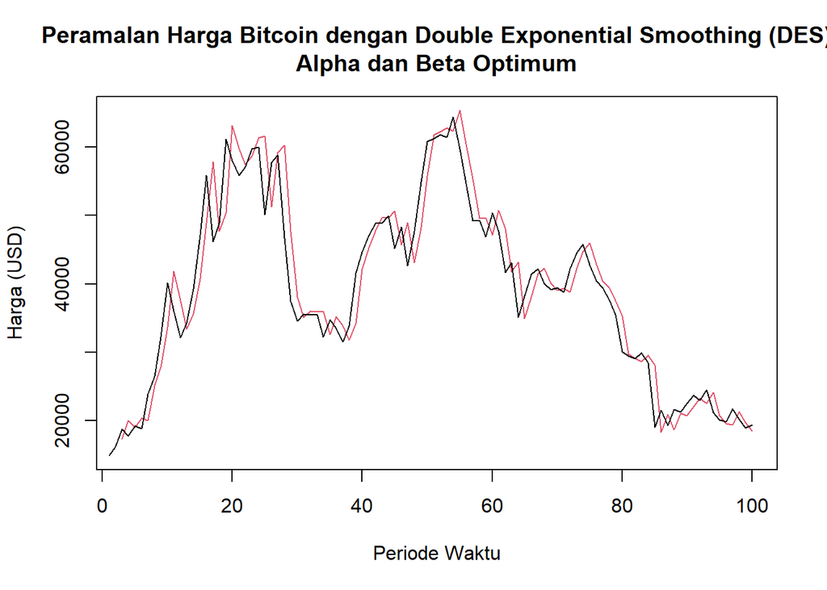

```r
plot(data_subset.des_opt, main = "Peramalan Harga Bitcoin dengan Double Exponential Smoothing (DES)\nAlpha dan Beta Optimum", xlab = "Periode Waktu", ylab = "Harga (USD)")
```

```r
# Ramalan 26 periode ke depan
data_subset.ramal.des_opt <- forecast(data_subset.des_opt, h = 26)
data_subset.ramal.des_opt
```

```
##     Point Forecast       Lo 80    Hi 80        Lo 95    Hi 95
## 101      18892.994  13446.2845 24339.70  10562.97068 27223.02
## 102      18474.088  10635.0205 26313.16   6485.26888 30462.91
## 103      18055.182   8286.5585 27823.81   3115.36167 32995.00
## 104      17636.276   6161.7511 29110.80     87.50465 35185.05
## 105      17217.370   4169.7598 30264.98  -2737.22754 37171.97
## 106      16798.463   2264.8742 31332.05  -5428.74315 39025.67
## 107      16379.557    420.4533 32338.66  -8027.78609 40786.90
## 108      15960.651  -1380.5275 33301.83 -10560.39308 42481.70
## 109      15541.745  -3149.6607 34233.15 -13044.29329 44127.78
## 110      15122.839  -4895.2157 35140.89 -15492.13382 45737.81
## 111      14703.933  -6623.3049 36031.17 -17913.26263 47321.13
## 112      14285.027  -8338.5742 36908.63 -20314.78515 48884.84
## 113      13866.121 -10044.6355 37776.88 -22702.22537 50434.47
## 114      13447.215 -11744.3495 38638.78 -25079.95804 51974.39
## 115      13028.309 -13440.0166 39496.63 -27451.50158 53508.12
## 116      12609.403 -15133.5112 40352.32 -29819.72271 55038.53
## 117      12190.497 -16826.3777 41207.37 -32186.98308 56567.98
## 118      11771.590 -18519.9003 42063.08 -34555.24680 58098.43
## 119      11352.684 -20215.1556 42920.52 -36926.16069 59631.53
## 120      10933.778 -21913.0531 43780.61 -39301.11528 61168.67
## 121      10514.872 -23614.3651 44644.11 -41681.29194 62711.04
## 122      10095.966 -25319.7513 45511.68 -44067.69959 64259.63
## 123       9677.060 -27029.7777 46383.90 -46461.20387 65815.32
## 124       9258.154 -28744.9319 47261.24 -48862.55035 67378.86
## 125       8839.248 -30465.6352 48144.13 -51272.38338 68950.88
## 126       8420.342 -32192.2526 49032.94 -53691.26139 70531.94
```

Selanjutnya akan dilakukan perhitungan akurasi pada data latih maupun data uji dengan ukuran akurasi SSE, MSE dan MAPE.

### **Akurasi Data Latih**

```r
# Akurasi Data Latih
# DES dengan alpha 0.2 dan beta 0.2
SSE_train.des1 <- data_subset.des1$SSE
MSE_train.des1 <- SSE_train.des1 / length(train_es.ts)
Sisaan_train.des1 <- data_subset.ramal.des1$residuals
head(Sisaan_train.des1)
```

```
## Time Series:
## Start = 1
## End = 6
## Frequency = 1
## [1]         NA         NA  1373.6000 -1155.1640  -759.6686 -2166.2856
```

```r
MAPE_train.des1 <- sum(abs(Sisaan_train.des1[3:length(train_es.ts)] / train_es.ts[3:length(train_es.ts)]) * 100) / length(train_es.ts)
akurasi_train.des1 <- matrix(c(SSE = SSE_train.des1, MSE = MSE_train.des1, MAPE = MAPE_train.des1))
colnames(akurasi_train.des1) <- c("Akurasi alpha = 0.2, beta = 0.2")
rownames(akurasi_train.des1) <- c("SSE", "MSE", "MAPE")
akurasi_train.des1
```

```
##      Akurasi alpha = 0.2, beta = 0.2
## SSE                     6.429208e+09
## MSE                     6.429208e+07
## MAPE                    1.599681e+01
```

```r
# DES dengan alpha 0.6 dan beta 0.3
SSE_train.des2 <- data_subset.des2$SSE
MSE_train.des2 <- SSE_train.des2 / length(train_es.ts)
Sisaan_train.des2 <- data_subset.ramal.des2$residuals
head(Sisaan_train.des2)
```

```
## Time Series:
## Start = 1
## End = 6
## Frequency = 1
## [1]         NA         NA  1373.6000 -1896.9080  -491.3678 -1594.1055
```

```r
MAPE_train.des2 <- sum(abs(Sisaan_train.des2[3:length(train_es.ts)] / train_es.ts[3:length(train_es.ts)]) * 100) / length(train_es.ts)
akurasi_train.des2 <- matrix(c(SSE = SSE_train.des2, MSE = MSE_train.des2, MAPE = MAPE_train.des2))
colnames(akurasi_train.des2) <- c("Akurasi alpha = 0.6, beta = 0.3")
rownames(akurasi_train.des2) <- c("SSE", "MSE", "MAPE")
akurasi_train.des2
```

```
##      Akurasi alpha = 0.6, beta = 0.3
## SSE                     2.177167e+09
## MSE                     2.177167e+07
## MAPE                    9.454220e+00
```

### **Akurasi Data Uji**

```r
# Akurasi Data Uji
selisih_test.des1 <- as.numeric(data_subset.ramal.des1$mean)[1:n_test] - as.numeric(test_es.ts)
selisih_test.des1
```

```
##  [1]  -1062.8328   -886.8451  -1193.2574  -2968.5697  -3630.6819    705.4058
##  [7]    631.0935    703.4812    105.1689   -307.8434   -128.0556   -358.4679
## [13]   -228.9802   -805.4925  -4990.4048  -6978.2171  -7400.7293  -7866.9416
## [19]  -6573.2539  -9515.1662  -8220.1785  -7571.4907  -5862.2030 -12479.1153
## [25] -13210.9276 -14361.7399
```

```r
SSE_test.des1 <- sum(selisih_test.des1^2)
MSE_test.des1 <- SSE_test.des1 / n_test
MAPE_test.des1 <- sum(abs(selisih_test.des1 / test_es.ts) * 100) / n_test

selisih_test.des2 <- as.numeric(data_subset.ramal.des2$mean)[1:n_test] - as.numeric(test_es.ts)
selisih_test.des2
```

```
##  [1]   -700.8985   -768.0740  -1317.6494  -3336.1249  -4241.4004   -148.4759
##  [7]   -465.9513   -636.7268  -1478.2023  -2134.3778  -2197.7532  -2671.3287
## [13]  -2785.0042  -3604.6796  -8032.7551 -10263.7306 -10929.4061 -11638.7815
## [19] -10588.2570 -13773.3325 -12721.5079 -12315.9834 -10849.8589 -17709.9344
## [25] -18684.9098 -20078.8853
```

```r
SSE_test.des2 <- sum(selisih_test.des2^2)
MSE_test.des2 <- SSE_test.des2 / n_test
MAPE_test.des2 <- sum(abs(selisih_test.des2 / test_es.ts) * 100) / n_test

selisih_test.des_opt <- as.numeric(data_subset.ramal.des_opt$mean)[1:n_test] - as.numeric(test_es.ts)
selisih_test.des_opt
```

```
##  [1]   -522.006087   -594.612175  -1149.618262  -3173.524349  -4084.230436
##  [6]      3.263476   -319.642611   -495.848698  -1342.754785  -2004.360873
## [11]  -2073.166960  -2552.173047  -2671.279134  -3496.385222  -7929.891309
## [16] -10166.297396 -10837.403484 -11552.209571 -10507.115658 -13697.621745
## [21] -12651.227833 -12251.133920 -10790.440007 -17655.946094 -18636.352182
## [26] -20035.758269
```

```r
SSE_test.des_opt <- sum(selisih_test.des_opt^2)
MSE_test.des_opt <- SSE_test.des_opt / n_test
MAPE_test.des_opt <- sum(abs(selisih_test.des_opt / test_es.ts) * 100) / n_test

akurasi_test.des <- rbind(
  c(SSE = SSE_test.des1, MSE = MSE_test.des1, MAPE = MAPE_test.des1),
  c(SSE = SSE_test.des2, MSE = MSE_test.des2, MAPE = MAPE_test.des2),
  c(SSE = SSE_test.des_opt, MSE = MSE_test.des_opt, MAPE = MAPE_test.des_opt)
)
akurasi_test.des <- as.data.frame(akurasi_test.des)
rownames(akurasi_test.des) <- c("Akurasi alpha = 0.2, beta = 0.2", "Akurasi alpha = 0.6, beta = 0.3", "Akurasi alpha dan beta optimum")
akurasi_test.des
```

```
##                                        SSE      MSE     MAPE
## Akurasi alpha = 0.2, beta = 0.2 1047462968 40287037 19.35753
## Akurasi alpha = 0.6, beta = 0.3 2295805172 88300199 30.72294
## Akurasi alpha dan beta optimum  2267259491 87202288 30.14829
```

## **Perbandingan SES dan DES**

```r
MAPE_test.Full2 <- matrix(c(
  MAPE_train.ses1_manual,
  MAPE_train.ses2_manual,
  MAPE_train.des1,
  MAPE_train.des2,
  MAPE_test.ses1,
  MAPE_test.ses2,
  MAPE_test.ses_opt,
  MAPE_test.des1,
  MAPE_test.des2,
  MAPE_test.des_opt
))
colnames(MAPE_test.Full2) <- c("MAPE")
rownames(MAPE_test.Full2) <- c("MAPE Data Latih SES alpha = 0.2",
                              "MAPE Data Latih SES alpha = 0.7",
                              "MAPE Data Latih DES alpha = 0.2, beta = 0.2",
                              "MAPE Data Latih DES alpha = 0.6, beta = 0.3",
                              "MAPE Data Uji SES alpha = 0.2",
                              "MAPE Data Uji SES alpha = 0.7",
                              "MAPE Data Uji SES alpha optimum",
                              "MAPE Data Uji DES alpha = 0.2, beta = 0.2",
                              "MAPE Data Uji DES alpha = 0.6, beta = 0.3",
                              "MAPE Data Uji DES alpha dan beta optimum")
MAPE_test.Full2
```

```
##                                                  MAPE
## MAPE Data Latih SES alpha = 0.2             16.831159
## MAPE Data Latih SES alpha = 0.7              8.548767
## MAPE Data Latih DES alpha = 0.2, beta = 0.2 15.996813
## MAPE Data Latih DES alpha = 0.6, beta = 0.3  9.454220
## MAPE Data Uji SES alpha = 0.2               14.791284
## MAPE Data Uji SES alpha = 0.7               14.236892
## MAPE Data Uji SES alpha optimum             14.238058
## MAPE Data Uji DES alpha = 0.2, beta = 0.2   19.357534
## MAPE Data Uji DES alpha = 0.6, beta = 0.3   30.722944
## MAPE Data Uji DES alpha dan beta optimum    30.148287
```